# Whoosh-bismillah

## Libs and Function

```r
library(ggplot2)
library(dplyr)
library(forecast)
library(TSA)
library(car)
library(lmtest)
library(tseries)
library(Rssa)
build_c <- function(r,groups){
  hasil <- r[[1]]
  for(i in 2:groups){
    hasil <- hasil + r[[i]]
  }
  return(hasil)
}
```

## Load Data

```r
dt <- read.csv("D:\\IPB\\5\\MPDW\\project\\9 whoosh\\whoosh_data.csv")
head(dt)
```

```
##   X    Tanggal brgkt  dtg passenger
## 1 1 2023-11-01  5850 5169     11019
## 2 2 2023-11-02  6838 5429     12267
## 3 3 2023-11-03  7358 6154     13512
## 4 4 2023-11-04  8977 8295     17272
## 5 5 2023-11-05  8446 7892     16338
## 6 6 2023-11-06  5952 6412     12364
```

### Fixing Formats

```r
dt <- dt %>% select(-X) %>%
  rename(tanggal = Tanggal) %>%
  mutate(tanggal = as.Date(tanggal, format = "%Y-%m-%d"))
str(dt)
```

```
## 'data.frame':    333 obs. of  4 variables:
##  $ tanggal  : Date, format: "2023-11-01" "2023-11-02" ...
##  $ brgkt    : int  5850 6838 7358 8977 8446 5952 6081 7156 7660 9399 ...
##  $ dtg      : int  5169 5429 6154 8295 7892 6412 6159 6498 6511 8227 ...
##  $ passenger: int  11019 12267 13512 17272 16338 12364 12240 13654 14171 17626 ...
```

### TS data

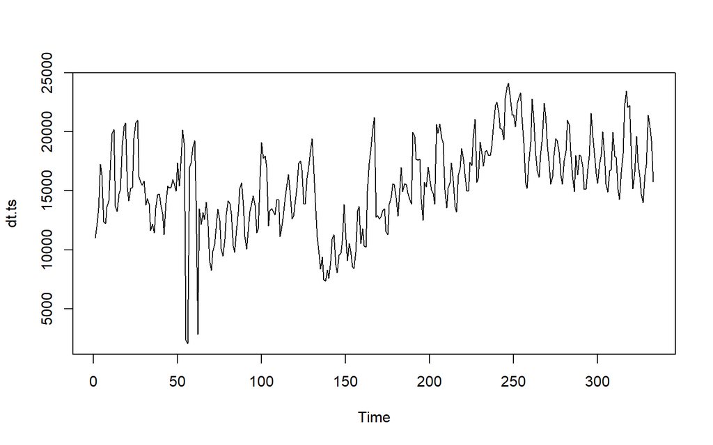

```r
dt.ts <- ts(dt$passenger)
plot(dt.ts)
```

## SARIMA

### Skenario 1

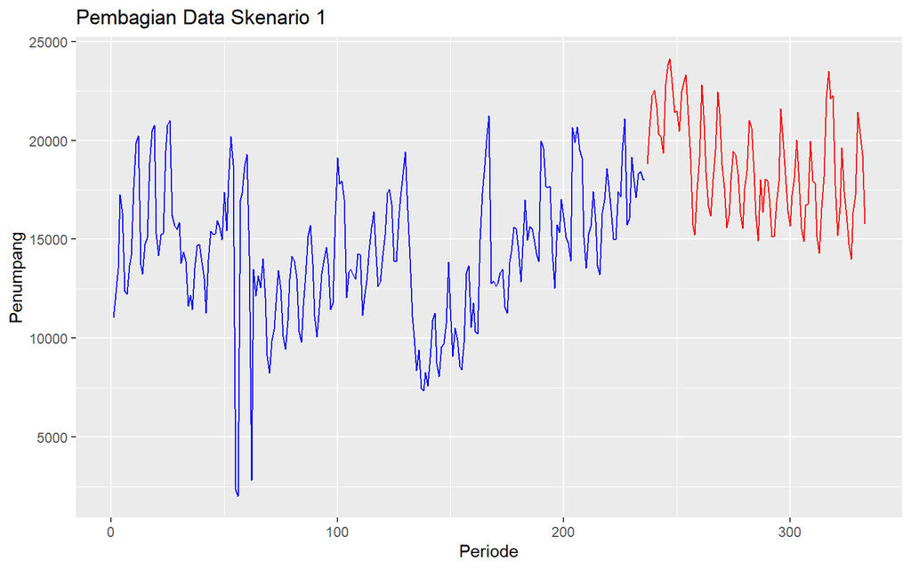

```r
train1 <- dt.ts[1:(round(length(dt.ts)*0.70)+3)] %>% ts()
test1 <- dt.ts[(round(length(dt.ts)*0.70)+4):length(dt.ts)] %>% ts()

ggplot()+
  geom_line(aes(x=1:length(train1), y=train1), color="blue")+
  geom_line(aes(x=(1:length(test1)+length(train1)), y=test1), color="red")+
  labs(title="Pembagian Data Skenario 1",
       x = "Periode",
       y = "Penumpang")
```

```r
#length(train1) #236
#length(test1) #97
```

#### Eksplorasi

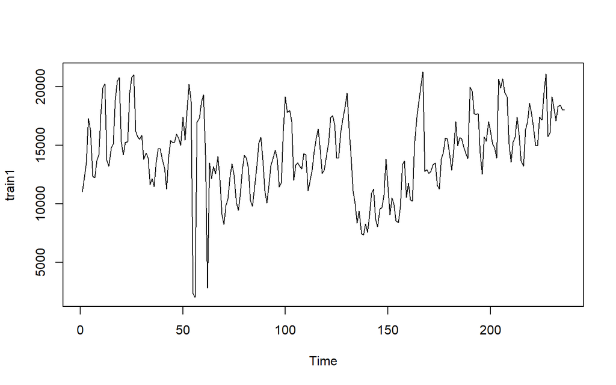

```r
plot(train1)
```

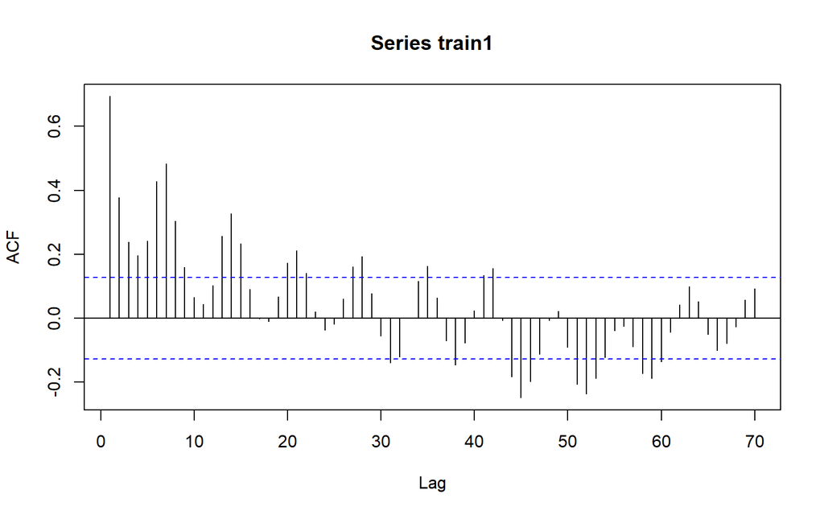

```r
acf(train1,lag.max = 70)
```

```r
adf.test(train1)
```

```
##
##  Augmented Dickey-Fuller Test
##
## data:  train1
## Dickey-Fuller = -2.4932, Lag order = 6, p-value = 0.3685
## alternative hypothesis: stationary
```

```r
index.train1 <- 1:length(train1)
bc.train1 <- boxCox(train1~index.train1, lambda = seq(-2, 2, 0.1))
```

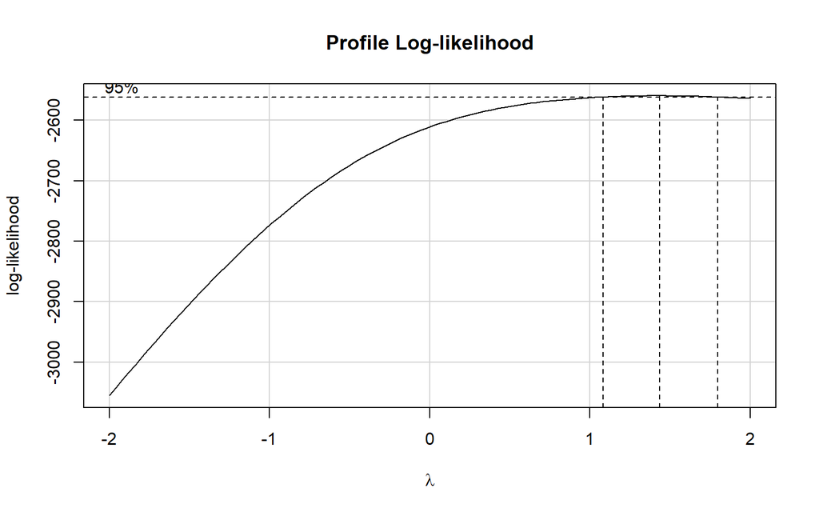

```r
lambda1 <- bc.train1$x[which(bc.train1$y == max(bc.train1$y))]
lambda1 # 1.4343
```

```
## [1] 1.434343
```

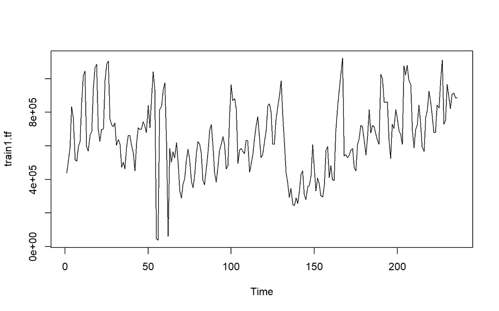

```r
train1.tf <- forecast::BoxCox(train1, lambda1)
plot(train1.tf)
```

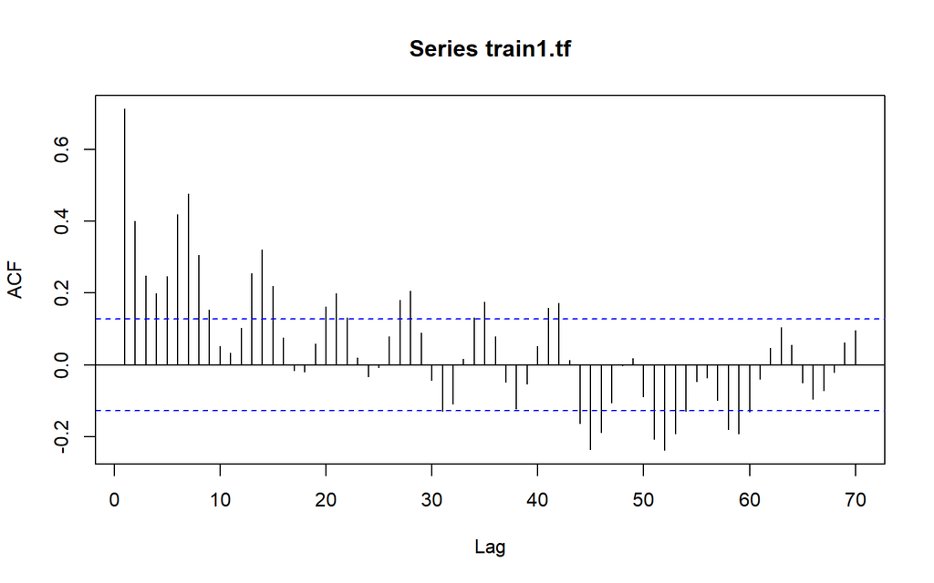

```r
acf(train1.tf,lag.max = 70)
```

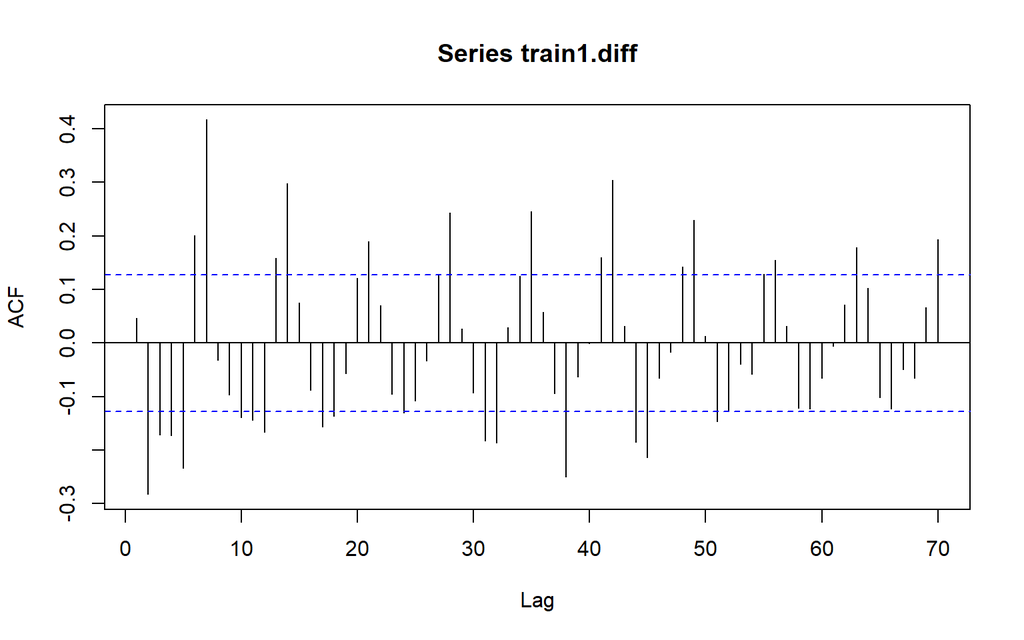

```r
train1.diff <- diff(train1.tf, lag = 1)
acf(train1.diff,lag.max=70)
```

```r
train1.diff2 <- diff(train1.diff, lag = 7)
```

#### Model Identification

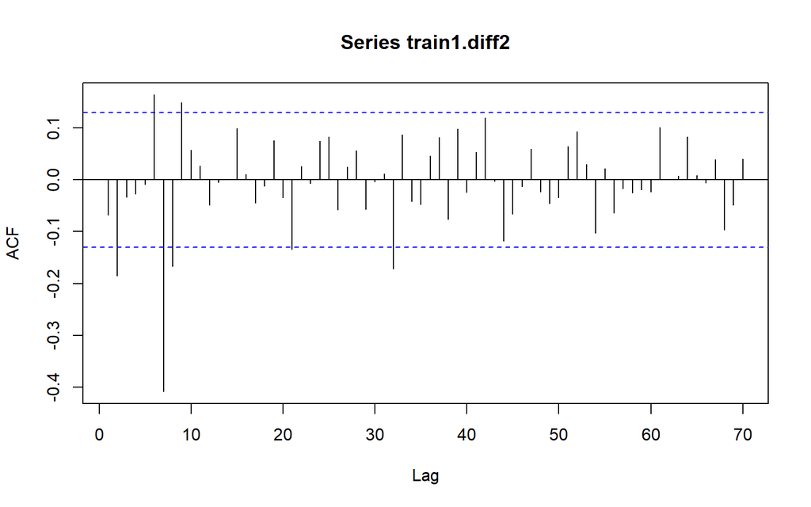

```r
acf(train1.diff2,lag.max=70)
```

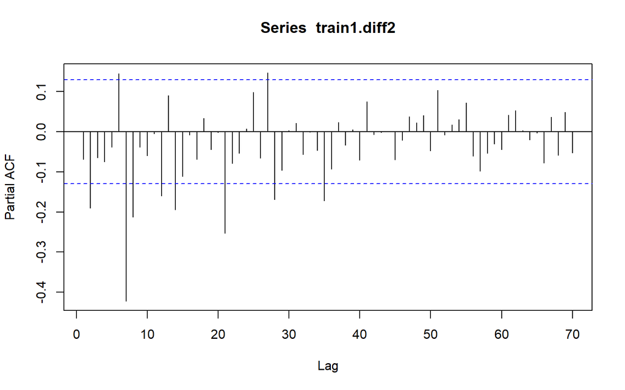

```r
pacf(train1.diff2,lag.max=70)
```

```r
eacf(train1.diff2)
```

```
## AR/MA
##   0 1 2 3 4 5 6 7 8 9 10 11 12 13
## 0 o x o o o x x x x o o  o  o  o
## 1 x x o o o o x x x o o  o  o  o
## 2 x x o o o o x x x o o  o  o  o
## 3 x x o o o o x x x o o  o  o  o
## 4 x o o o o o x x o o o  o  o  o
## 5 x o o o x o x x x o o  o  o  o
## 6 x o x x x x x x o o x  o  o  o
## 7 x o x o x x x x x x x  o  o  o
```

Model Tentatif 1. ARIMA(0,1,2)(0,1,1)[7] 2. ARIMA(2,1,0)(0,1,1)[7] 3. ARIMA(2,1,2)(0,1,1)[7] 4. ARIMA(0,1,2)(5,1,0)[7] 5. ARIMA(2,1,0)(5,1,0)[7] 6. ARIMA(2,1,2)(5,1,0)[7]

#### Pendugaan Parameter

```r
model1.1 <- Arima(train1, order = c(0,1,2), seasonal = list(order = c(0,1,1), period = 7),lambda = lambda1)
summary(model1.1)
```

```
## Series: train1
## ARIMA(0,1,2)(0,1,1)[7]
## Box Cox transformation: lambda= 1.434343
##
## Coefficients:
##           ma1      ma2     sma1
##       -0.2099  -0.3361  -0.8621
## s.e.   0.0646   0.0671   0.0406
##
## sigma^2 = 1.755e+10:  log likelihood = -3016.09
## AIC=6040.17   AICc=6040.35   BIC=6053.89
##
## Training set error measures:
##                     ME     RMSE     MAE       MPE     MAPE      MASE       ACF1
## Training set -55.99491 2156.854 1450.22 -4.438238 14.18572 0.8590746 0.03619684
```

```r
coeftest(model1.1)
```

```
##
## z test of coefficients:
##
##       Estimate Std. Error  z value  Pr(>|z|)
## ma1  -0.209936   0.064647  -3.2474  0.001165 **
## ma2  -0.336085   0.067134  -5.0062 5.552e-07 ***
## sma1 -0.862059   0.040579 -21.2442 < 2.2e-16 ***
## ---
## Signif. codes:  0 '***' 0.001 '**' 0.01 '*' 0.05 '.' 0.1 ' ' 1
```

```r
aic1.1 <- AIC(model1.1)
sigs1.1 <- "all"
```

```r
model1.2 <- Arima(train1, order = c(2,1,0), seasonal = list(order = c(0,1,1), period = 7),lambda = lambda1)
summary(model1.2)
```

```
## Series: train1
## ARIMA(2,1,0)(0,1,1)[7]
## Box Cox transformation: lambda= 1.434343
##
## Coefficients:
##           ar1      ar2     sma1
##       -0.1072  -0.2584  -0.8486
## s.e.   0.0639   0.0640   0.0423
##
## sigma^2 = 1.822e+10:  log likelihood = -3019.85
## AIC=6047.71   AICc=6047.89   BIC=6061.43
##
## Training set error measures:
##                     ME     RMSE      MAE       MPE     MAPE      MASE
## Training set -20.06428 2208.792 1492.216 -3.630176 14.24815 0.8839517
##                     ACF1
## Training set -0.01852864
```

```r
coeftest(model1.2)
```

```
##
## z test of coefficients:
##
##       Estimate Std. Error  z value  Pr(>|z|)
## ar1  -0.107243   0.063871  -1.6790   0.09314 .
## ar2  -0.258426   0.063979  -4.0392 5.363e-05 ***
## sma1 -0.848613   0.042251 -20.0848 < 2.2e-16 ***
## ---
## Signif. codes:  0 '***' 0.001 '**' 0.01 '*' 0.05 '.' 0.1 ' ' 1
```

```r
aic1.2 <- AIC(model1.2)
sigs1.2 <- "1 not sig"
```

```r
model1.3 <- Arima(train1, order = c(2,1,2), seasonal = list(order = c(0,1,1), period = 7),lambda = lambda1)
summary(model1.3)
```

```
## Series: train1
## ARIMA(2,1,2)(0,1,1)[7]
## Box Cox transformation: lambda= 1.434343
##
## Coefficients:
##           ar1     ar2     ma1      ma2     sma1
##       -0.2609  0.6513  0.0294  -0.9588  -0.8360
## s.e.   0.0679  0.0692  0.0404   0.0416   0.0495
##
## sigma^2 = 1.706e+10:  log likelihood = -3012.9
## AIC=6037.8   AICc=6038.18   BIC=6058.37
##
## Training set error measures:
##                     ME     RMSE      MAE       MPE     MAPE      MASE
## Training set -9.454351 2116.832 1441.844 -4.129953 13.88199 0.8541128
##                    ACF1
## Training set 0.01947644
```

```r
coeftest(model1.3)
```

```
##
## z test of coefficients:
##
##       Estimate Std. Error  z value  Pr(>|z|)
## ar1  -0.260893   0.067921  -3.8411 0.0001225 ***
## ar2   0.651279   0.069245   9.4055 < 2.2e-16 ***
## ma1   0.029387   0.040383   0.7277 0.4667984
## ma2  -0.958794   0.041630 -23.0315 < 2.2e-16 ***
## sma1 -0.836035   0.049496 -16.8908 < 2.2e-16 ***
## ---
## Signif. codes:  0 '***' 0.001 '**' 0.01 '*' 0.05 '.' 0.1 ' ' 1
```

```r
aic1.3 <- AIC(model1.3)
sigs1.3 <- "not sig 1"
```

```r
model1.4 <- Arima(train1, order = c(0,1,2), seasonal = list(order = c(5,1,0), period = 7),lambda = lambda1)
summary(model1.4)
```

```
## Series: train1
## ARIMA(0,1,2)(5,1,0)[7]
## Box Cox transformation: lambda= 1.434343
##
## Coefficients:
##           ma1      ma2     sar1     sar2     sar3     sar4     sar5
##       -0.2044  -0.3317  -0.7454  -0.5999  -0.5656  -0.4055  -0.2300
## s.e.   0.0656   0.0700   0.0664   0.0812   0.0813   0.0810   0.0671
##
## sigma^2 = 1.787e+10:  log likelihood = -3015.26
## AIC=6046.51   AICc=6047.17   BIC=6073.95
##
## Training set error measures:
##                     ME     RMSE      MAE       MPE     MAPE     MASE       ACF1
## Training set -46.28517 2153.833 1475.435 -4.131107 14.20616 0.874011 0.03379052
```

```r
coeftest(model1.4)
```

```
##
## z test of coefficients:
##
##       Estimate Std. Error  z value  Pr(>|z|)
## ma1  -0.204381   0.065578  -3.1166 0.0018294 **
## ma2  -0.331665   0.069966  -4.7403 2.134e-06 ***
## sar1 -0.745369   0.066420 -11.2220 < 2.2e-16 ***
## sar2 -0.599885   0.081158  -7.3916 1.451e-13 ***
## sar3 -0.565567   0.081305  -6.9561 3.498e-12 ***
## sar4 -0.405501   0.080997  -5.0064 5.546e-07 ***
## sar5 -0.229968   0.067073  -3.4286 0.0006067 ***
## ---
## Signif. codes:  0 '***' 0.001 '**' 0.01 '*' 0.05 '.' 0.1 ' ' 1
```

```r
aic1.4 <- AIC(model1.4)
sigs1.4 <- "all"
```

```r
model1.5 <- Arima(train1, order = c(2,1,0), seasonal = list(order = c(5,1,0), period = 7),lambda = lambda1)
summary(model1.5)
```

```
## Series: train1
## ARIMA(2,1,0)(5,1,0)[7]
## Box Cox transformation: lambda= 1.434343
##
## Coefficients:
##           ar1      ar2     sar1     sar2     sar3     sar4     sar5
##       -0.1201  -0.2736  -0.7240  -0.5808  -0.5614  -0.3958  -0.2243
## s.e.   0.0641   0.0657   0.0664   0.0796   0.0802   0.0804   0.0668
##
## sigma^2 = 1.833e+10:  log likelihood = -3017.93
## AIC=6051.85   AICc=6052.51   BIC=6079.29
##
## Training set error measures:
##                     ME     RMSE      MAE       MPE     MAPE      MASE
## Training set -14.34499 2188.414 1500.281 -3.377809 14.10956 0.8887294
##                      ACF1
## Training set -0.009438622
```

```r
coeftest(model1.5)
```

```
##
## z test of coefficients:
##
##       Estimate Std. Error  z value  Pr(>|z|)
## ar1  -0.120054   0.064097  -1.8730 0.0610666 .
## ar2  -0.273574   0.065683  -4.1651 3.112e-05 ***
## sar1 -0.723998   0.066403 -10.9031 < 2.2e-16 ***
## sar2 -0.580783   0.079557  -7.3002 2.873e-13 ***
## sar3 -0.561399   0.080163  -7.0032 2.502e-12 ***
## sar4 -0.395801   0.080404  -4.9227 8.537e-07 ***
## sar5 -0.224322   0.066810  -3.3576 0.0007862 ***
## ---
## Signif. codes:  0 '***' 0.001 '**' 0.01 '*' 0.05 '.' 0.1 ' ' 1
```

```r
aic1.5 <- AIC(model1.5)
sigs1.5 <- "1 not sig"
```

```r
model1.6 <- Arima(train1, order = c(2,1,2), seasonal = list(order = c(5,1,0), period = 7),lambda = lambda1)
summary(model1.6)
```

```
## Series: train1
## ARIMA(2,1,2)(5,1,0)[7]
## Box Cox transformation: lambda= 1.434343
##
## Coefficients:
##          ar1     ar2      ma1      ma2     sar1     sar2     sar3     sar4
##       0.3083  0.2381  -0.5050  -0.4671  -0.6521  -0.5113  -0.4914  -0.3304
## s.e.  0.2445  0.1882   0.2304   0.2268   0.0671   0.0794   0.0797   0.0800
##          sar5
##       -0.2027
## s.e.   0.0680
##
## sigma^2 = 1.737e+10:  log likelihood = -3011.82
## AIC=6043.63   AICc=6044.65   BIC=6077.93
##
## Training set error measures:
##                     ME    RMSE      MAE       MPE    MAPE      MASE        ACF1
## Training set -6.090779 2106.16 1442.381 -3.899706 13.6048 0.8544305 -0.02127718
```

```r
coeftest(model1.6)
```

```
##
## z test of coefficients:
##
##       Estimate Std. Error z value  Pr(>|z|)
## ar1   0.308321   0.244505  1.2610  0.207309
## ar2   0.238122   0.188237  1.2650  0.205867
## ma1  -0.505034   0.230439 -2.1916  0.028407 *
## ma2  -0.467064   0.226828 -2.0591  0.039483 *
## sar1 -0.652132   0.067083 -9.7212 < 2.2e-16 ***
## sar2 -0.511293   0.079429 -6.4371 1.218e-10 ***
## sar3 -0.491420   0.079653 -6.1695 6.851e-10 ***
## sar4 -0.330427   0.080013 -4.1297 3.633e-05 ***
## sar5 -0.202664   0.067965 -2.9819  0.002865 **
## ---
## Signif. codes:  0 '***' 0.001 '**' 0.01 '*' 0.05 '.' 0.1 ' ' 1
```

```r
aic1.6 <- AIC(model1.6)
sigs1.6 <- "not sig 2"
```

#### Model Selection

```r
aic1 <- c(aic1.1, aic1.2, aic1.3, aic1.4, aic1.5, aic1.6)
sigs1 <- c(sigs1.1, sigs1.2, sigs1.3, sigs1.4, sigs1.5, sigs1.6)
model1 <- c("ARIMA(0,1,2)(0,1,1)[7]", "ARIMA(2,1,0)(0,1,1)[7]", "ARIMA(2,1,2)(0,1,1)[7]", "ARIMA(0,1,2)(5,1,0)[7]", "ARIMA(2,1,0)(5,1,0)[7]", "ARIMA(2,1,2)(5,1,0)[7]")
summary1 <- data.frame(model1, aic1, sigs1)
summary1
```

```
##                   model1     aic1     sigs1
## 1 ARIMA(0,1,2)(0,1,1)[7] 6040.173       all
## 2 ARIMA(2,1,0)(0,1,1)[7] 6047.710 1 not sig
## 3 ARIMA(2,1,2)(0,1,1)[7] 6037.797 not sig 1
## 4 ARIMA(0,1,2)(5,1,0)[7] 6046.511       all
## 5 ARIMA(2,1,0)(5,1,0)[7] 6051.850 1 not sig
## 6 ARIMA(2,1,2)(5,1,0)[7] 6043.633 not sig 2
```

#### Overfitting Underfitting

```r
of1.1 <- Arima(train1, order = c(1,1,2), seasonal = list(order = c(0,1,1), period = 7),lambda = lambda1)
summary(of1.1)
```

```
## Series: train1
## ARIMA(1,1,2)(0,1,1)[7]
## Box Cox transformation: lambda= 1.434343
##
## Coefficients:
##          ar1      ma1     ma2     sma1
##       0.4892  -0.6729  -0.215  -0.8523
## s.e.  0.2215   0.2347   0.124   0.0463
##
## sigma^2 = 1.72e+10:  log likelihood = -3013.73
## AIC=6037.45   AICc=6037.72   BIC=6054.6
##
## Training set error measures:
##                     ME     RMSE      MAE       MPE     MAPE      MASE
## Training set -50.32744 2124.321 1449.288 -4.272979 13.78705 0.8585223
##                     ACF1
## Training set -0.01780332
```

```r
coeftest(of1.1)
```

```
##
## z test of coefficients:
##
##       Estimate Std. Error  z value  Pr(>|z|)
## ar1   0.489188   0.221474   2.2088  0.027189 *
## ma1  -0.672904   0.234704  -2.8670  0.004143 **
## ma2  -0.215045   0.123991  -1.7344  0.082853 .
## sma1 -0.852319   0.046292 -18.4120 < 2.2e-16 ***
## ---
## Signif. codes:  0 '***' 0.001 '**' 0.01 '*' 0.05 '.' 0.1 ' ' 1
```

```r
aic.of1.1 <- AIC(of1.1)
sigs.of1.1 <- "not sig"
```

```r
of1.2 <- Arima(train1, order = c(1,1,1), seasonal = list(order = c(0,1,1), period = 7),lambda = lambda1)
summary(of1.2)
```

```
## Series: train1
## ARIMA(1,1,1)(0,1,1)[7]
## Box Cox transformation: lambda= 1.434343
##
## Coefficients:
##          ar1      ma1     sma1
##       0.6986  -0.9676  -0.8291
## s.e.  0.0602   0.0290   0.0508
##
## sigma^2 = 1.728e+10:  log likelihood = -3014.98
## AIC=6037.97   AICc=6038.15   BIC=6051.69
##
## Training set error measures:
##                     ME     RMSE      MAE       MPE     MAPE      MASE
## Training set -5.798446 2149.235 1455.444 -4.314869 14.15941 0.8621692
##                    ACF1
## Training set 0.03397034
```

```r
coeftest(of1.2)
```

```
##
## z test of coefficients:
##
##       Estimate Std. Error z value  Pr(>|z|)
## ar1   0.698606   0.060203  11.604 < 2.2e-16 ***
## ma1  -0.967590   0.028952 -33.420 < 2.2e-16 ***
## sma1 -0.829136   0.050787 -16.326 < 2.2e-16 ***
## ---
## Signif. codes:  0 '***' 0.001 '**' 0.01 '*' 0.05 '.' 0.1 ' ' 1
```

```r
aic.of1.2 <- AIC(of1.2)
sigs.of1.2 <- "sig"
```

```r
of1.3 <- Arima(train1, order = c(1,1,1), seasonal = list(order = c(0,1,2), period = 7),lambda = lambda1)
summary(of1.3)
```

```
## Series: train1
## ARIMA(1,1,1)(0,1,2)[7]
## Box Cox transformation: lambda= 1.434343
##
## Coefficients:
##          ar1      ma1     sma1     sma2
##       0.6953  -0.9686  -0.7211  -0.1308
## s.e.  0.0573   0.0252   0.0657   0.0611
##
## sigma^2 = 1.7e+10:  log likelihood = -3012.76
## AIC=6035.53   AICc=6035.8   BIC=6052.67
##
## Training set error measures:
##                     ME     RMSE      MAE       MPE     MAPE      MASE
## Training set 0.6804337 2120.816 1428.511 -4.106003 13.81976 0.8462148
##                    ACF1
## Training set 0.04248345
```

```r
coeftest(of1.3)
```

```
##
## z test of coefficients:
##
##       Estimate Std. Error  z value Pr(>|z|)
## ar1   0.695315   0.057338  12.1266  < 2e-16 ***
## ma1  -0.968565   0.025223 -38.4004  < 2e-16 ***
## sma1 -0.721118   0.065657 -10.9831  < 2e-16 ***
## sma2 -0.130802   0.061112  -2.1404  0.03233 *
## ---
## Signif. codes:  0 '***' 0.001 '**' 0.01 '*' 0.05 '.' 0.1 ' ' 1
```

```r
aic.of1.3 <- AIC(of1.3)
sigs.of1.3 <- "sig"
```

```r
of1.4 <- Arima(train1, order = c(1,1,1), seasonal = list(order = c(1,1,1), period = 7),lambda = lambda1)
summary(of1.4)
```

```
## Series: train1
## ARIMA(1,1,1)(1,1,1)[7]
## Box Cox transformation: lambda= 1.434343
##
## Coefficients:
##          ar1      ma1    sar1     sma1
##       0.6956  -0.9694  0.1697  -0.8805
## s.e.  0.0567   0.0246  0.0780   0.0438
##
## sigma^2 = 1.698e+10:  log likelihood = -3012.61
## AIC=6035.22   AICc=6035.49   BIC=6052.37
##
## Training set error measures:
##                    ME     RMSE      MAE       MPE     MAPE      MASE       ACF1
## Training set 1.334961 2119.855 1426.922 -4.090362 13.80982 0.8452734 0.04195064
```

```r
coeftest(of1.4)
```

```
##
## z test of coefficients:
##
##       Estimate Std. Error  z value Pr(>|z|)
## ar1   0.695596   0.056750  12.2573  < 2e-16 ***
## ma1  -0.969447   0.024600 -39.4090  < 2e-16 ***
## sar1  0.169698   0.077991   2.1759  0.02957 *
## sma1 -0.880507   0.043844 -20.0825  < 2e-16 ***
## ---
## Signif. codes:  0 '***' 0.001 '**' 0.01 '*' 0.05 '.' 0.1 ' ' 1
```

```r
aic.of1.4 <- AIC(of1.4)
sigs.of1.4 <- "sig"
```

```r
of1.5 <- Arima(train1, order = c(0,1,3), seasonal = list(order = c(0,1,1), period = 7),lambda = lambda1)
summary(of1.5)
```

```
## Series: train1
## ARIMA(0,1,3)(0,1,1)[7]
## Box Cox transformation: lambda= 1.434343
##
## Coefficients:
##           ma1      ma2      ma3     sma1
##       -0.1768  -0.3477  -0.1238  -0.8626
## s.e.   0.0676   0.0653   0.0684   0.0406
##
## sigma^2 = 1.734e+10:  log likelihood = -3014.41
## AIC=6038.83   AICc=6039.1   BIC=6055.98
##
## Training set error measures:
##                     ME     RMSE      MAE       MPE     MAPE      MASE
## Training set -61.37349 2129.769 1455.472 -4.335718 13.93003 0.8621853
##                      ACF1
## Training set -0.002123477
```

```r
coeftest(of1.5)
```

```
##
## z test of coefficients:
##
##       Estimate Std. Error  z value  Pr(>|z|)
## ma1  -0.176751   0.067595  -2.6149  0.008926 **
## ma2  -0.347701   0.065316  -5.3234 1.019e-07 ***
## ma3  -0.123838   0.068358  -1.8116  0.070047 .
## sma1 -0.862602   0.040598 -21.2473 < 2.2e-16 ***
## ---
## Signif. codes:  0 '***' 0.001 '**' 0.01 '*' 0.05 '.' 0.1 ' ' 1
```

##### Summary OF

```r
aic.of1 <- c(aic.of1.1, aic.of1.2, aic.of1.3, aic.of1.4)
sigs.of1 <- c(sigs.of1.1, sigs.of1.2, sigs.of1.3, sigs.of1.4)
model.of1 <- c("ARIMA(1,1,2)(0,1,1)[7]", "ARIMA(1,1,1)(0,1,1)[7]", "ARIMA(1,1,1)(0,1,2)[7]", "ARIMA(1,1,1)(1,1,1)[7]")
summary.of1 <- data.frame(model.of1, aic.of1, sigs.of1)
summary.of1
```

```
##                model.of1  aic.of1 sigs.of1
## 1 ARIMA(1,1,2)(0,1,1)[7] 6037.453  not sig
## 2 ARIMA(1,1,1)(0,1,1)[7] 6037.968      sig
## 3 ARIMA(1,1,1)(0,1,2)[7] 6035.528      sig
## 4 ARIMA(1,1,1)(1,1,1)[7] 6035.225      sig
```

ARIMA(1,1,1)(1,1,1)[7] lambda 1.4343 is the best model

```r
model.fix1 <- Arima(train1, order = c(1,1,1), seasonal = list(order = c(1,1,1), period = 7),lambda = lambda1)
```

#### Diagnostik Sisaan

```r
sisaan1 <- residuals(model.fix1)
ks.test(sisaan1, "pnorm")
```

```
##
##  Asymptotic one-sample Kolmogorov-Smirnov test
##
## data:  sisaan1
## D = 0.5, p-value < 2.2e-16
## alternative hypothesis: two-sided
```

```r
Box.test(sisaan1, type = "Ljung-Box")
```

```
##
##  Box-Ljung test
##
## data:  sisaan1
## X-squared = 0.78478, df = 1, p-value = 0.3757
```

```r
Box.test(sisaan1^2, type = "Ljung-Box")
```

```
##
##  Box-Ljung test
##
## data:  sisaan1^2
## X-squared = 1.7627, df = 1, p-value = 0.1843
```

#### Performa Model

```r
## train
accuracy(model.fix1$fitted, train1) # 13.81 % MAPE
```

```
##                ME     RMSE      MAE       MPE     MAPE       ACF1 Theil's U
## Test set 1.334961 2119.855 1426.922 -4.090362 13.80982 0.04195064 0.6866029
```

```r
## Test
test1.f <- forecast::forecast(model.fix1, h = length(test1))
accuracy(ts(test1.f$mean), ts(test1)) # 13.33 % MAPE
```

```
##                 ME    RMSE      MAE       MPE     MAPE      ACF1 Theil's U
## Test set -465.4796 2907.81 2414.073 -4.460073 13.33427 0.8043751  1.513956
```

### Skenario 2

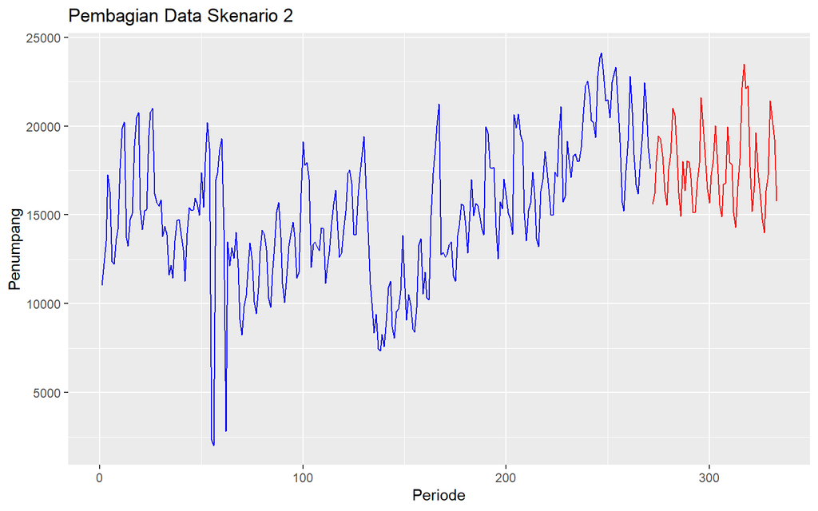

```r
train2 <- dt.ts[1:(round(length(dt.ts)*0.80)+5)] %>% ts()
test2 <- dt.ts[(round(length(dt.ts)*0.80)+6):length(dt.ts)] %>% ts()

ggplot()+
  geom_line(aes(x=1:length(train2), y=train2), color="blue")+
  geom_line(aes(x=(1:length(test2)+length(train2)), y=test2), color="red")+
  labs(title="Pembagian Data Skenario 2",
       x = "Periode",
       y = "Penumpang")
```

```r
# length(train2) # 271
# length(test2) # 62
```

#### Eksplorasi

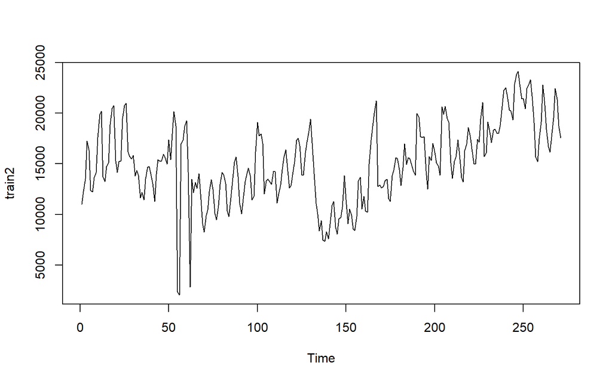

```r
plot(train2)
```

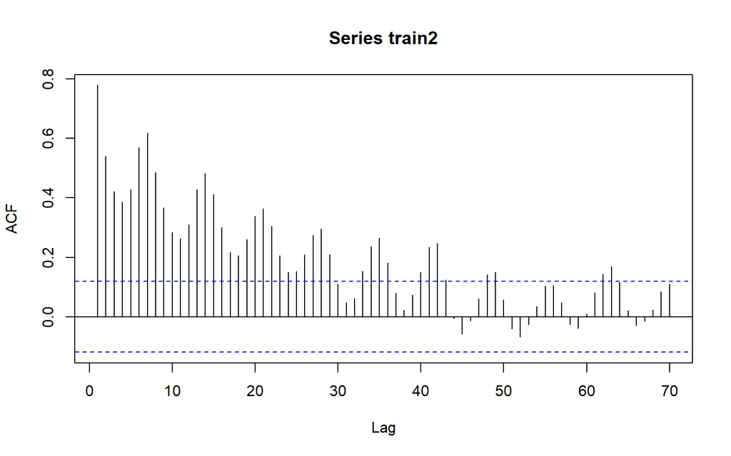

```r
acf(train2,lag.max = 70)
```

```r
adf.test(train2)
```

```
##
##  Augmented Dickey-Fuller Test
##
## data:  train2
## Dickey-Fuller = -2.4068, Lag order = 6, p-value = 0.4046
## alternative hypothesis: stationary
```

```r
index.train2 <- 1:length(train2)
bc.train2 <- boxCox(train2~index.train2, lambda = seq(-2, 2, 0.1))
```

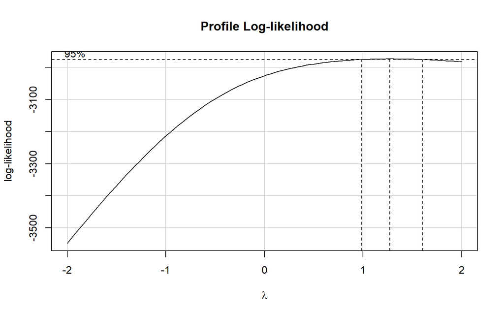

```r
lambda2 <- bc.train2$x[which(bc.train2$y == max(bc.train2$y))]
lambda2
```

```
## [1] 1.272727
```

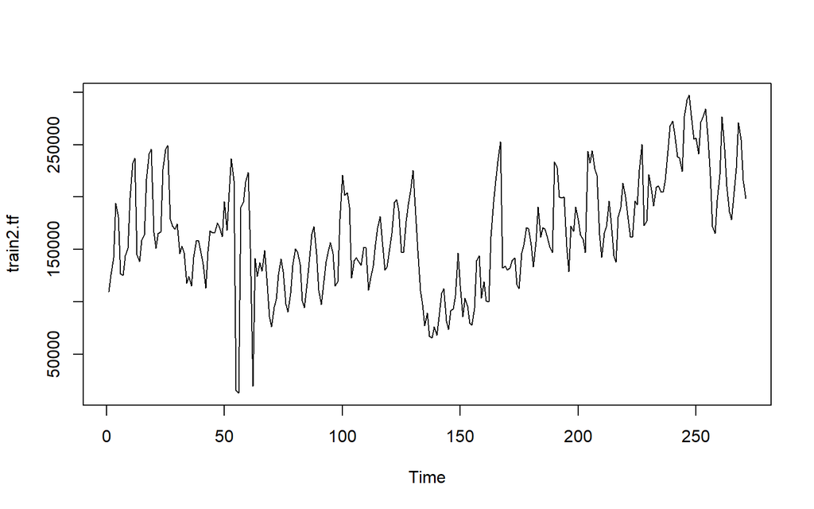

```r
train2.tf <- forecast::BoxCox(train2, lambda2)
plot(train2.tf)
```

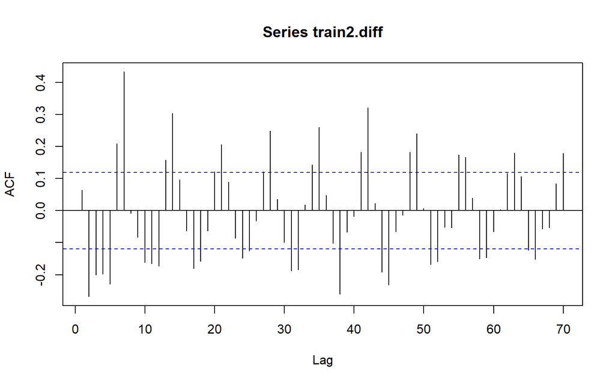

```r
train2.diff <- diff(train2.tf, lag = 1)
acf(train2.diff,lag.max=70)
```

```r
train2.diff2 <- diff(train2.diff, lag = 7)
```

#### Model Identification

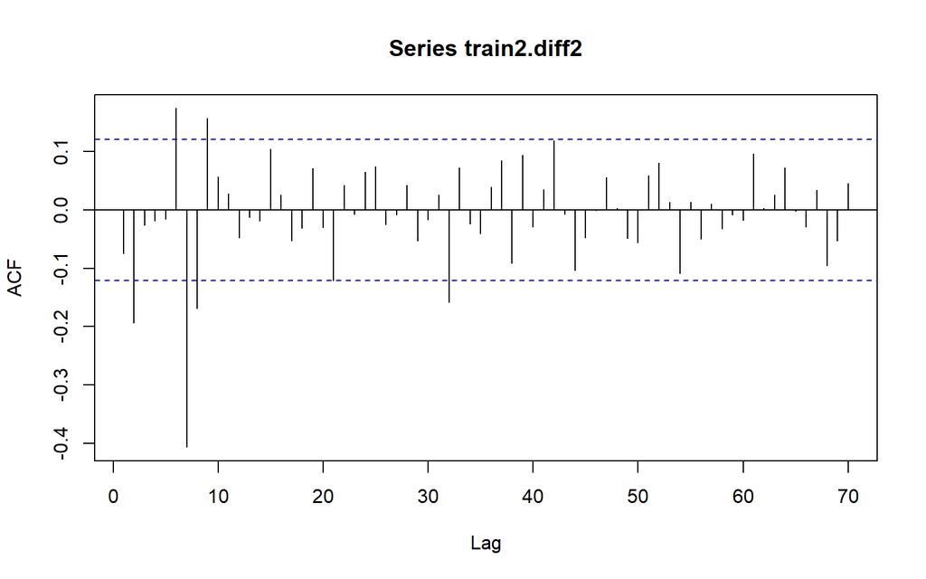

```r
acf(train2.diff2,lag.max=70)
```

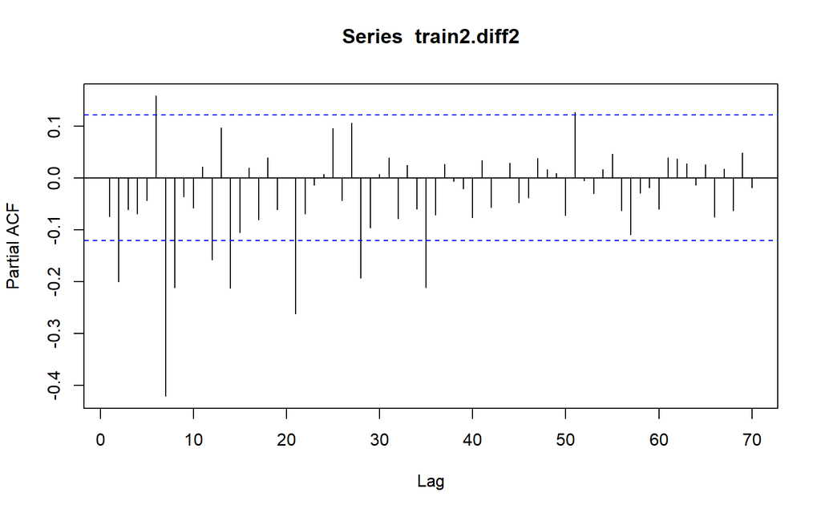

```r
pacf(train2.diff2,lag.max=70)
```

```r
eacf(train2.diff2)
```

```
## AR/MA
##   0 1 2 3 4 5 6 7 8 9 10 11 12 13
## 0 o x o o o x x x x o o  o  o  o
## 1 x x o o o o x x x o o  o  o  o
## 2 x x o o o o x o x o o  o  o  o
## 3 x x o o o o x x x o o  o  o  o
## 4 x o o o o o x x o o o  o  o  o
## 5 x o o o x o x x o o o  o  o  o
## 6 x o x x x x x x o o x  o  o  o
## 7 x o o x x x x x o x x  o  o  o
```

Model Tentatif 1. ARIMA(0,1,2)(0,1,1)[7] 2. ARIMA(2,1,0)(0,1,1)[7] 3. ARIMA(2,1,2)(0,1,1)[7] 4. ARIMA(0,1,2)(5,1,0)[7] 5. ARIMA(2,1,0)(5,1,0)[7] 6. ARIMA(2,1,2)(5,1,0)[7]

#### Pendugaan Parameter

```r
model2.1 <- Arima(train2, order = c(0,1,2), seasonal = list(order = c(0,1,1), period = 7),lambda = lambda2)
summary(model2.1)
```

```
## Series: train2
## ARIMA(0,1,2)(0,1,1)[7]
## Box Cox transformation: lambda= 1.272727
##
## Coefficients:
##           ma1      ma2     sma1
##       -0.2036  -0.3153  -0.8247
## s.e.   0.0603   0.0624   0.0422
##
## sigma^2 = 778415743:  log likelihood = -3068.03
## AIC=6144.06   AICc=6144.22   BIC=6158.35
##
## Training set error measures:
##                     ME     RMSE      MAE       MPE     MAPE      MASE
## Training set -54.69913 2081.913 1392.279 -3.876936 12.93131 0.8365925
##                    ACF1
## Training set 0.03133839
```

```r
coeftest(model2.1)
```

```
##
## z test of coefficients:
##
##       Estimate Std. Error  z value  Pr(>|z|)
## ma1  -0.203637   0.060301  -3.3770 0.0007328 ***
## ma2  -0.315274   0.062417  -5.0511 4.393e-07 ***
## sma1 -0.824729   0.042173 -19.5557 < 2.2e-16 ***
## ---
## Signif. codes:  0 '***' 0.001 '**' 0.01 '*' 0.05 '.' 0.1 ' ' 1
```

```r
aic2.1 <- AIC(model2.1)
sigs2.1 <- "all"
```

```r
model2.2 <- Arima(train2, order = c(2,1,0), seasonal = list(order = c(0,1,1), period = 7),lambda = lambda2)
summary(model2.2)
```

```
## Series: train2
## ARIMA(2,1,0)(0,1,1)[7]
## Box Cox transformation: lambda= 1.272727
##
## Coefficients:
##           ar1      ar2     sma1
##       -0.1056  -0.2377  -0.8063
## s.e.   0.0599   0.0598   0.0439
##
## sigma^2 = 8.06e+08:  log likelihood = -3072.16
## AIC=6152.31   AICc=6152.47   BIC=6166.6
##
## Training set error measures:
##                     ME     RMSE      MAE       MPE     MAPE      MASE
## Training set -28.64645 2125.203 1426.592 -3.272652 12.97672 0.8572103
##                     ACF1
## Training set -0.02401044
```

```r
coeftest(model2.2)
```

```
##
## z test of coefficients:
##
##       Estimate Std. Error  z value  Pr(>|z|)
## ar1  -0.105638   0.059855  -1.7649   0.07758 .
## ar2  -0.237746   0.059789  -3.9764 6.997e-05 ***
## sma1 -0.806261   0.043895 -18.3681 < 2.2e-16 ***
## ---
## Signif. codes:  0 '***' 0.001 '**' 0.01 '*' 0.05 '.' 0.1 ' ' 1
```

```r
aic2.2 <- AIC(model2.2)
sigs2.2 <- "1 not sig"
```

```r
model2.3 <- Arima(train2, order = c(2,1,2), seasonal = list(order = c(0,1,1), period = 7),lambda = lambda2)
summary(model2.3)
```

```
## Series: train2
## ARIMA(2,1,2)(0,1,1)[7]
## Box Cox transformation: lambda= 1.272727
##
## Coefficients:
##           ar1     ar2     ma1      ma2     sma1
##       -0.2379  0.6784  0.0162  -0.9622  -0.7987
## s.e.   0.0587  0.0591  0.0290   0.0295   0.0501
##
## sigma^2 = 754316827:  log likelihood = -3064.03
## AIC=6140.06   AICc=6140.39   BIC=6161.49
##
## Training set error measures:
##                   ME     RMSE      MAE      MPE     MAPE      MASE       ACF1
## Training set 5.27598 2045.824 1384.926 -3.53425 12.67485 0.8321743 0.01238592
```

```r
coeftest(model2.3)
```

```
##
## z test of coefficients:
##
##       Estimate Std. Error  z value  Pr(>|z|)
## ar1  -0.237877   0.058683  -4.0536 5.043e-05 ***
## ar2   0.678441   0.059085  11.4824 < 2.2e-16 ***
## ma1   0.016189   0.029028   0.5577     0.577
## ma2  -0.962156   0.029507 -32.6082 < 2.2e-16 ***
## sma1 -0.798655   0.050119 -15.9351 < 2.2e-16 ***
## ---
## Signif. codes:  0 '***' 0.001 '**' 0.01 '*' 0.05 '.' 0.1 ' ' 1
```

```r
aic2.3 <- AIC(model2.3)
sigs2.3 <- "not sig 1"
```

```r
model2.4 <- Arima(train2, order = c(0,1,2), seasonal = list(order = c(5,1,0), period = 7),lambda = lambda2)
summary(model2.4)
```

```
## Series: train2
## ARIMA(0,1,2)(5,1,0)[7]
## Box Cox transformation: lambda= 1.272727
##
## Coefficients:
##           ma1      ma2     sar1     sar2     sar3     sar4     sar5
##       -0.1972  -0.3142  -0.7168  -0.5739  -0.5242  -0.3806  -0.2127
## s.e.   0.0614   0.0653   0.0611   0.0732   0.0735   0.0726   0.0605
##
## sigma^2 = 780075036:  log likelihood = -3065.88
## AIC=6147.76   AICc=6148.33   BIC=6176.34
##
## Training set error measures:
##                     ME     RMSE      MAE       MPE     MAPE      MASE
## Training set -43.45882 2069.081 1401.803 -3.578385 12.85304 0.8423156
##                    ACF1
## Training set 0.02897894
```

```r
coeftest(model2.4)
```

```
##
## z test of coefficients:
##
##       Estimate Std. Error  z value  Pr(>|z|)
## ma1  -0.197163   0.061446  -3.2087 0.0013332 **
## ma2  -0.314158   0.065263  -4.8137 1.482e-06 ***
## sar1 -0.716838   0.061097 -11.7327 < 2.2e-16 ***
## sar2 -0.573944   0.073209  -7.8398 4.514e-15 ***
## sar3 -0.524182   0.073476  -7.1340 9.748e-13 ***
## sar4 -0.380600   0.072553  -5.2458 1.556e-07 ***
## sar5 -0.212677   0.060512  -3.5146 0.0004404 ***
## ---
## Signif. codes:  0 '***' 0.001 '**' 0.01 '*' 0.05 '.' 0.1 ' ' 1
```

```r
aic2.4 <- AIC(model2.4)
sigs2.4 <- "all"
```

```r
model2.5 <- Arima(train2, order = c(2,1,0), seasonal = list(order = c(5,1,0), period = 7),lambda = lambda2)
summary(model2.5)
```

```
## Series: train2
## ARIMA(2,1,0)(5,1,0)[7]
## Box Cox transformation: lambda= 1.272727
##
## Coefficients:
##           ar1      ar2     sar1     sar2     sar3     sar4     sar5
##       -0.1134  -0.2501  -0.6950  -0.5537  -0.5139  -0.3650  -0.2054
## s.e.   0.0602   0.0609   0.0608   0.0719   0.0721   0.0716   0.0602
##
## sigma^2 = 800678124:  log likelihood = -3069.04
## AIC=6154.08   AICc=6154.65   BIC=6182.66
##
## Training set error measures:
##                     ME     RMSE      MAE       MPE     MAPE      MASE
## Training set -20.98555 2099.949 1414.746 -3.013896 12.71786 0.8500926
##                     ACF1
## Training set -0.01663969
```

```r
coeftest(model2.5)
```

```
##
## z test of coefficients:
##
##       Estimate Std. Error  z value  Pr(>|z|)
## ar1  -0.113429   0.060200  -1.8842 0.0595375 .
## ar2  -0.250058   0.060931  -4.1040 4.061e-05 ***
## sar1 -0.694997   0.060850 -11.4216 < 2.2e-16 ***
## sar2 -0.553669   0.071876  -7.7031 1.328e-14 ***
## sar3 -0.513931   0.072136  -7.1245 1.045e-12 ***
## sar4 -0.365026   0.071575  -5.0999 3.398e-07 ***
## sar5 -0.205352   0.060219  -3.4101 0.0006494 ***
## ---
## Signif. codes:  0 '***' 0.001 '**' 0.01 '*' 0.05 '.' 0.1 ' ' 1
```

```r
aic2.5 <- AIC(model2.5)
sigs2.5 <- "1 not sig"
```

```r
model2.6 <- Arima(train2, order = c(2,1,2), seasonal = list(order = c(5,1,0), period = 7),lambda = lambda2)
summary(model2.6)
```

```
## Series: train2
## ARIMA(2,1,2)(5,1,0)[7]
## Box Cox transformation: lambda= 1.272727
##
## Coefficients:
##          ar1     ar2      ma1      ma2     sar1     sar2     sar3     sar4
##       0.3179  0.2493  -0.5104  -0.4624  -0.6347  -0.5024  -0.4691  -0.3247
## s.e.  0.2510  0.1935   0.2381   0.2344   0.0614   0.0715   0.0718   0.0711
##          sar5
##       -0.1977
## s.e.   0.0612
##
## sigma^2 = 753462880:  log likelihood = -3061.29
## AIC=6142.57   AICc=6143.45   BIC=6178.29
##
## Training set error measures:
##                    ME     RMSE      MAE       MPE     MAPE      MASE
## Training set 11.01891 2023.877 1361.017 -3.293999 12.28596 0.8178077
##                     ACF1
## Training set -0.02310964
```

```r
coeftest(model2.6)
```

```
##
## z test of coefficients:
##
##       Estimate Std. Error  z value  Pr(>|z|)
## ar1   0.317885   0.251003   1.2665  0.205348
## ar2   0.249266   0.193504   1.2882  0.197687
## ma1  -0.510403   0.238099  -2.1437  0.032060 *
## ma2  -0.462391   0.234430  -1.9724  0.048563 *
## sar1 -0.634704   0.061432 -10.3318 < 2.2e-16 ***
## sar2 -0.502448   0.071494  -7.0279 2.097e-12 ***
## sar3 -0.469062   0.071823  -6.5308 6.542e-11 ***
## sar4 -0.324738   0.071106  -4.5669 4.949e-06 ***
## sar5 -0.197671   0.061152  -3.2324  0.001227 **
## ---
## Signif. codes:  0 '***' 0.001 '**' 0.01 '*' 0.05 '.' 0.1 ' ' 1
```

```r
aic2.6 <- AIC(model2.6)
sigs2.6 <- "not sig 2"
```

#### Model Selection

```r
aic2 <- c(aic2.1, aic2.2, aic2.3, aic2.4, aic2.5, aic2.6)
sigs2 <- c(sigs2.1, sigs2.2, sigs2.3, sigs2.4, sigs2.5, sigs2.6)
model2 <- c("ARIMA(0,1,2)(0,1,1)[7]", "ARIMA(2,1,0)(0,1,1)[7]", "ARIMA(2,1,2)(0,1,1)[7]", "ARIMA(0,1,2)(5,1,0)[7]", "ARIMA(2,1,0)(5,1,0)[7]", "ARIMA(2,1,2)(5,1,0)[7]")
summary2 <- data.frame(model2, aic2, sigs2)
summary2
```

```
##                   model2     aic2     sigs2
## 1 ARIMA(0,1,2)(0,1,1)[7] 6144.062       all
## 2 ARIMA(2,1,0)(0,1,1)[7] 6152.311 1 not sig
## 3 ARIMA(2,1,2)(0,1,1)[7] 6140.057 not sig 1
## 4 ARIMA(0,1,2)(5,1,0)[7] 6147.763       all
## 5 ARIMA(2,1,0)(5,1,0)[7] 6154.084 1 not sig
## 6 ARIMA(2,1,2)(5,1,0)[7] 6142.573 not sig 2
```

#### Overfitting Underfitting

```r
of2.1 <- Arima(train2, order = c(1,1,2), seasonal = list(order = c(0,1,1), period = 7),lambda = lambda2)
summary(of2.1)
```

```
## Series: train2
## ARIMA(1,1,2)(0,1,1)[7]
## Box Cox transformation: lambda= 1.272727
##
## Coefficients:
##          ar1      ma1      ma2     sma1
##       0.6370  -0.8242  -0.1335  -0.8020
## s.e.  0.1112   0.1392   0.1082   0.0548
##
## sigma^2 = 7.59e+08:  log likelihood = -3065.13
## AIC=6140.26   AICc=6140.49   BIC=6158.12
##
## Training set error measures:
##                     ME     RMSE     MAE       MPE     MAPE      MASE
## Training set -11.34161 2054.041 1397.76 -3.562001 12.62577 0.8398862
##                     ACF1
## Training set -0.02188461
```

```r
coeftest(of2.1)
```

```
##
## z test of coefficients:
##
##       Estimate Std. Error  z value  Pr(>|z|)
## ar1   0.637016   0.111236   5.7267 1.024e-08 ***
## ma1  -0.824186   0.139158  -5.9227 3.168e-09 ***
## ma2  -0.133476   0.108215  -1.2334    0.2174
## sma1 -0.801987   0.054795 -14.6361 < 2.2e-16 ***
## ---
## Signif. codes:  0 '***' 0.001 '**' 0.01 '*' 0.05 '.' 0.1 ' ' 1
```

```r
aic.of2.1 <- AIC(of2.1)
sigs.of2.1 <- "not sig 1"
```

```r
of2.2 <- Arima(train2, order = c(1,1,1), seasonal = list(order = c(0,1,1), period = 7),lambda = lambda2)
summary(of2.2)
```

```
## Series: train2
## ARIMA(1,1,1)(0,1,1)[7]
## Box Cox transformation: lambda= 1.272727
##
## Coefficients:
##          ar1     ma1     sma1
##       0.7222  -0.975  -0.7911
## s.e.  0.0511   0.021   0.0513
##
## sigma^2 = 760623232:  log likelihood = -3065.9
## AIC=6139.8   AICc=6139.95   BIC=6154.08
##
## Training set error measures:
##                   ME     RMSE      MAE       MPE     MAPE      MASE       ACF1
## Training set 8.10324 2066.941 1396.123 -3.655454 12.86252 0.8389023 0.02711408
```

```r
coeftest(of2.2)
```

```
##
## z test of coefficients:
##
##       Estimate Std. Error z value  Pr(>|z|)
## ar1   0.722155   0.051071  14.140 < 2.2e-16 ***
## ma1  -0.974958   0.021042 -46.334 < 2.2e-16 ***
## sma1 -0.791139   0.051266 -15.432 < 2.2e-16 ***
## ---
## Signif. codes:  0 '***' 0.001 '**' 0.01 '*' 0.05 '.' 0.1 ' ' 1
```

```r
aic.of2.2 <- AIC(of2.2)
sigs.of2.2 <- "sig"
```

```r
of2.3 <- Arima(train2, order = c(1,1,1), seasonal = list(order = c(0,1,2), period = 7),lambda = lambda2)
summary(of2.3)
```

```
## Series: train2
## ARIMA(1,1,1)(0,1,2)[7]
## Box Cox transformation: lambda= 1.272727
##
## Coefficients:
##          ar1      ma1     sma1     sma2
##       0.7116  -0.9719  -0.6865  -0.1374
## s.e.  0.0513   0.0206   0.0604   0.0567
##
## sigma^2 = 746345751:  log likelihood = -3063.07
## AIC=6136.13   AICc=6136.37   BIC=6153.99
##
## Training set error measures:
##                    ME     RMSE      MAE       MPE    MAPE      MASE       ACF1
## Training set 13.54761 2039.215 1355.296 -3.472143 12.4543 0.8143702 0.03817192
```

```r
coeftest(of2.3)
```

```
##
## z test of coefficients:
##
##       Estimate Std. Error  z value Pr(>|z|)
## ar1   0.711587   0.051343  13.8594  < 2e-16 ***
## ma1  -0.971906   0.020551 -47.2925  < 2e-16 ***
## sma1 -0.686491   0.060354 -11.3744  < 2e-16 ***
## sma2 -0.137353   0.056683  -2.4232  0.01538 *
## ---
## Signif. codes:  0 '***' 0.001 '**' 0.01 '*' 0.05 '.' 0.1 ' ' 1
```

```r
aic.of2.3 <- AIC(of2.3)
sigs.of2.3 <- "sig"
```

```r
of2.4 <- Arima(train2, order = c(1,1,1), seasonal = list(order = c(1,1,1), period = 7),lambda = lambda2)
summary(of2.4)
```

```
## Series: train2
## ARIMA(1,1,1)(1,1,1)[7]
## Box Cox transformation: lambda= 1.272727
##
## Coefficients:
##          ar1      ma1    sar1     sma1
##       0.7109  -0.9721  0.1835  -0.8611
## s.e.  0.0511   0.0202  0.0743   0.0435
##
## sigma^2 = 745319659:  log likelihood = -3062.9
## AIC=6135.79   AICc=6136.03   BIC=6153.65
##
## Training set error measures:
##                    ME     RMSE      MAE       MPE     MAPE      MASE       ACF1
## Training set 14.50735 2038.152 1353.174 -3.456793 12.44273 0.8130949 0.03778546
```

```r
coeftest(of2.4)
```

```
##
## z test of coefficients:
##
##       Estimate Std. Error  z value Pr(>|z|)
## ar1   0.710898   0.051065  13.9215  < 2e-16 ***
## ma1  -0.972078   0.020178 -48.1753  < 2e-16 ***
## sar1  0.183513   0.074333   2.4688  0.01356 *
## sma1 -0.861132   0.043514 -19.7900  < 2e-16 ***
## ---
## Signif. codes:  0 '***' 0.001 '**' 0.01 '*' 0.05 '.' 0.1 ' ' 1
```

```r
aic.of2.4 <- AIC(of2.4)
sigs.of2.4 <- "sig"
```

```r
of2.5 <- Arima(train2, order = c(0,1,3), seasonal = list(order = c(0,1,1), period = 7),lambda = lambda2)
summary(of2.5)
```

```
## Series: train2
## ARIMA(0,1,3)(0,1,1)[7]
## Box Cox transformation: lambda= 1.272727
##
## Coefficients:
##           ma1      ma2      ma3     sma1
##       -0.1719  -0.3227  -0.1225  -0.8309
## s.e.   0.0626   0.0603   0.0617   0.0423
##
## sigma^2 = 7.68e+08:  log likelihood = -3066.04
## AIC=6142.07   AICc=6142.31   BIC=6159.93
##
## Training set error measures:
##                     ME     RMSE      MAE       MPE     MAPE      MASE
## Training set -61.33159 2060.029 1397.123 -3.801048 12.72752 0.8395033
##                    ACF1
## Training set -0.0053936
```

```r
coeftest(of2.5)
```

```
##
## z test of coefficients:
##
##       Estimate Std. Error  z value  Pr(>|z|)
## ma1  -0.171948   0.062596  -2.7470  0.006015 **
## ma2  -0.322687   0.060349  -5.3470 8.942e-08 ***
## ma3  -0.122474   0.061748  -1.9835  0.047317 *
## sma1 -0.830851   0.042298 -19.6427 < 2.2e-16 ***
## ---
## Signif. codes:  0 '***' 0.001 '**' 0.01 '*' 0.05 '.' 0.1 ' ' 1
```

##### Summary OF

```r
aic.of2 <- c(aic.of2.1,aic.of2.2, aic.of2.3, aic.of2.4)
sigs.of2 <- c(sigs.of2.1, sigs.of2.2, sigs.of2.3, sigs.of2.4)
model.of2 <- c("ARIMA(1,1,2)(0,1,1)[7]", "ARIMA(1,1,1)(0,1,1)[7]", "ARIMA(1,1,1)(0,1,2)[7]", "ARIMA(1,1,1)(1,1,1)[7]")
summary.of2 <- data.frame(model.of2, aic.of2, sigs.of2)
summary.of2
```

```
##                model.of2  aic.of2  sigs.of2
## 1 ARIMA(1,1,2)(0,1,1)[7] 6140.259 not sig 1
## 2 ARIMA(1,1,1)(0,1,1)[7] 6139.796       sig
## 3 ARIMA(1,1,1)(0,1,2)[7] 6136.132       sig
## 4 ARIMA(1,1,1)(1,1,1)[7] 6135.793       sig
```

ARIMA(1,1,1)(1,1,1)[7] lambda 1.2727 is the best model

```r
model.fix2 <- Arima(train2, order = c(1,1,1), seasonal = list(order = c(1,1,1), period = 7),lambda = lambda2)
```

#### Diagnostik Sisaan

```r
sisaan2 <- residuals(model.fix2)
ks.test(sisaan2, "pnorm")
```

```
##
##  Asymptotic one-sample Kolmogorov-Smirnov test
##
## data:  sisaan2
## D = 0.50923, p-value < 2.2e-16
## alternative hypothesis: two-sided
```

```r
Box.test(sisaan2, type = "Ljung-Box")
```

```
##
##  Box-Ljung test
##
## data:  sisaan2
## X-squared = 0.73853, df = 1, p-value = 0.3901
```

```r
Box.test(sisaan2^2, type = "Ljung-Box")
```

```
##
##  Box-Ljung test
##
## data:  sisaan2^2
## X-squared = 1.9878, df = 1, p-value = 0.1586
```

#### Performa Model

```r
## train
accuracy(model.fix2$fitted, train2) # 12.44 % MAPE
```

```
##                ME     RMSE      MAE       MPE     MAPE       ACF1 Theil's U
## Test set 14.50735 2038.152 1353.174 -3.456793 12.44273 0.03778546  0.718181
```

```r
## Test
test2.f <- forecast::forecast(model.fix2, h = length(test2))
accuracy(ts(test2.f$mean), ts(test2)) # 21.56 % MAPE
```

```
##                 ME     RMSE     MAE       MPE     MAPE     ACF1 Theil's U
## Test set -3612.707 4025.994 3626.13 -21.50018 21.56046 0.621996   2.12545
```

### Skenario 3

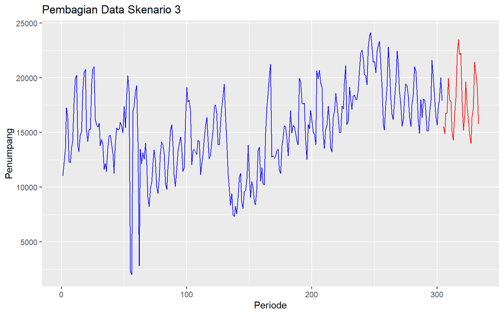

```r
train3 <- dt.ts[1:(round(length(dt.ts)*0.90)+4)] %>% ts()
test3 <- dt.ts[(round(length(dt.ts)*0.90)+5):length(dt.ts)] %>% ts()

ggplot()+
  geom_line(aes(x=1:length(train3), y=train3), color="blue")+
  geom_line(aes(x=(1:length(test3)+length(train3)), y=test3), color="red")+
  labs(title="Pembagian Data Skenario 3",
       x = "Periode",
       y = "Penumpang")
```

```r
# length(train3) # 304
# length(test3) # 29
```

#### Eksplorasi

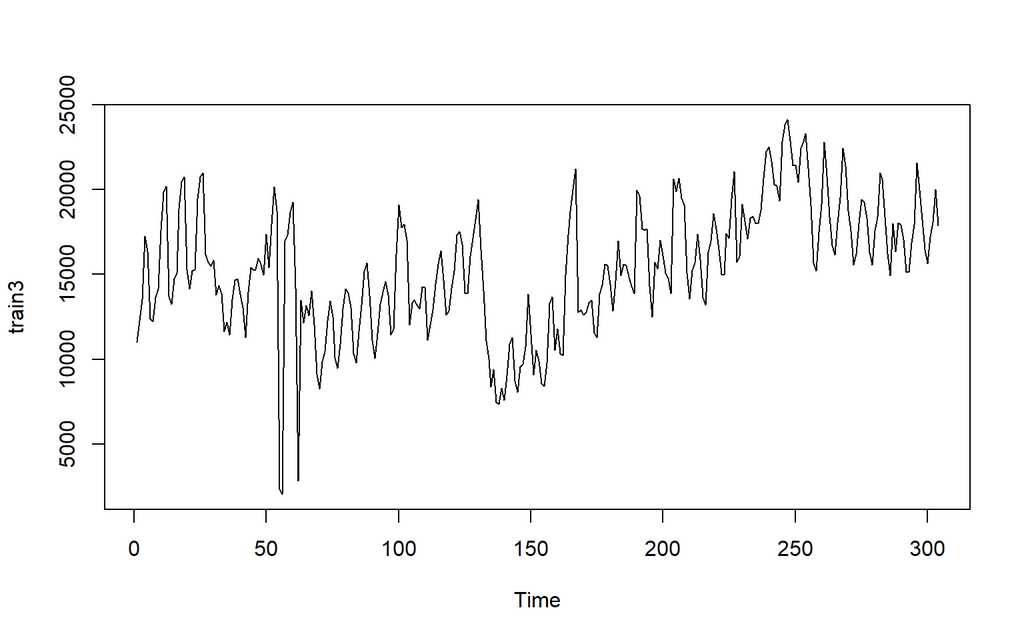

```r
plot(train3)
```

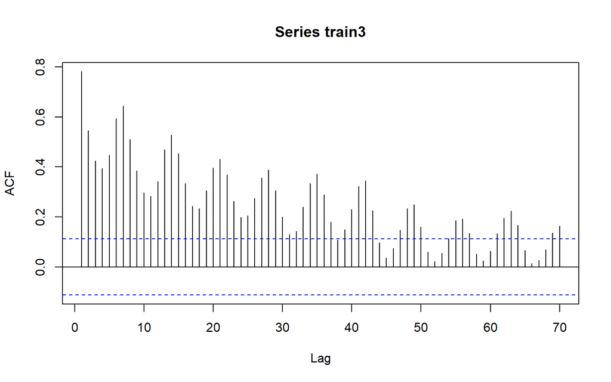

```r
acf(train3,lag.max = 70)
```

```r
adf.test(train3)
```

```
##
##  Augmented Dickey-Fuller Test
##
## data:  train3
## Dickey-Fuller = -2.5787, Lag order = 6, p-value = 0.3324
## alternative hypothesis: stationary
```

```r
index.train3 <- 1:length(train3)
bc.train3 <- boxCox(train3~index.train3, lambda = seq(-2, 2, 0.1))
```

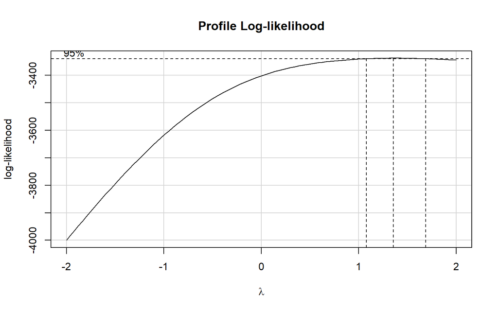

```r
lambda3 <- bc.train3$x[which(bc.train3$y == max(bc.train3$y))]
```

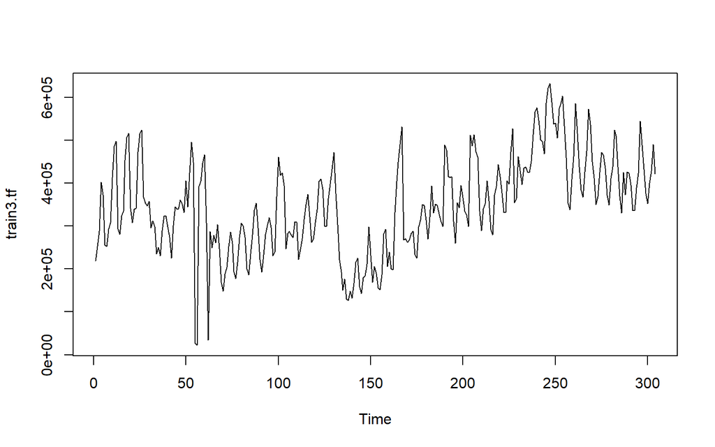

```r
train3.tf <- forecast::BoxCox(train3, lambda3)
plot(train3.tf)
```

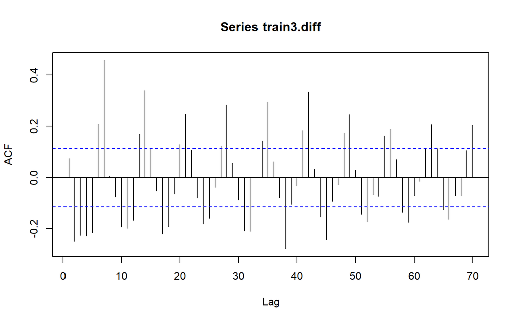

```r
train3.diff <- diff(train3.tf, lag = 1)
acf(train3.diff,lag.max=70)
```

```r
train3.diff2 <- diff(train3.diff, lag = 7)
adf.test(train3.diff2)
```

```
##
##  Augmented Dickey-Fuller Test
##
## data:  train3.diff2
## Dickey-Fuller = -10.054, Lag order = 6, p-value = 0.01
## alternative hypothesis: stationary
```

#### Model Identification

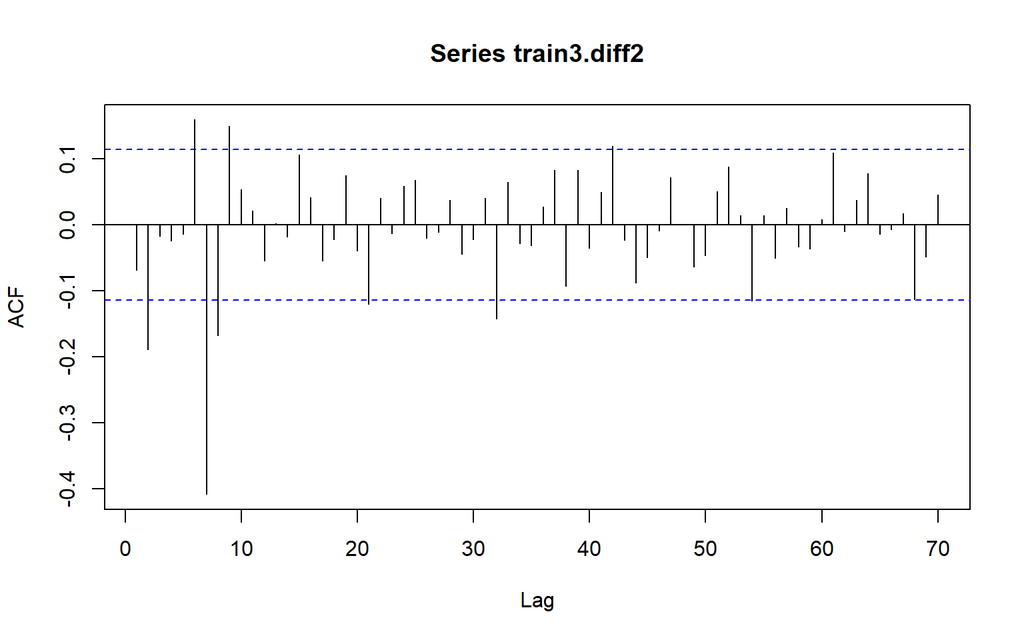

```r
acf(train3.diff2,lag.max=70)
```

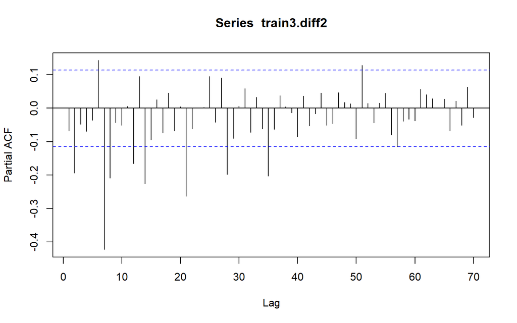

```r
pacf(train3.diff2,lag.max=70)
```

```r
eacf(train3.diff2)
```

```
## AR/MA
##   0 1 2 3 4 5 6 7 8 9 10 11 12 13
## 0 o x o o o x x x x o o  o  o  o
## 1 x x o o o o x x x o o  o  o  o
## 2 x x o o o o x x x o o  o  o  o
## 3 x x o o o o x x o o o  o  o  o
## 4 x x o o o o x x o o o  o  o  o
## 5 x o o o x o x x o o o  o  o  o
## 6 x o x x x x x x o o x  o  x  o
## 7 x o o o x x x x o o o  o  x  o
```

Model Tentatif 1. ARIMA(0,1,2)(0,1,1)[7] 2. ARIMA(2,1,0)(0,1,1)[7] 3. ARIMA(2,1,2)(0,1,1)[7] 4. ARIMA(0,1,2)(5,1,0)[7] 5. ARIMA(2,1,0)(5,1,0)[7] 6. ARIMA(2,1,2)(5,1,0)[7]

#### Pendugaan Parameter

```r
model3.1 <- Arima(train3, order = c(0,1,2), seasonal = list(order = c(0,1,1), period = 7),lambda = lambda3)
summary(model3.1)
```

```
## Series: train3
## ARIMA(0,1,2)(0,1,1)[7]
## Box Cox transformation: lambda= 1.353535
##
## Coefficients:
##           ma1      ma2     sma1
##       -0.1958  -0.3077  -0.8162
## s.e.   0.0576   0.0601   0.0383
##
## sigma^2 = 3.304e+09:  log likelihood = -3666.46
## AIC=7340.91   AICc=7341.05   BIC=7355.67
##
## Training set error measures:
##                     ME    RMSE      MAE       MPE     MAPE      MASE       ACF1
## Training set -59.39834 1992.96 1320.924 -3.525265 12.02231 0.8024557 0.02987279
```

```r
coeftest(model3.1)
```

```
##
## z test of coefficients:
##
##       Estimate Std. Error  z value  Pr(>|z|)
## ma1  -0.195812   0.057629  -3.3978 0.0006793 ***
## ma2  -0.307696   0.060108  -5.1191 3.071e-07 ***
## sma1 -0.816249   0.038295 -21.3150 < 2.2e-16 ***
## ---
## Signif. codes:  0 '***' 0.001 '**' 0.01 '*' 0.05 '.' 0.1 ' ' 1
```

```r
aic3.1 <- AIC(model3.1)
sigs3.1 <- "all"
```

```r
model3.2 <- Arima(train3, order = c(2,1,0), seasonal = list(order = c(0,1,1), period = 7),lambda = lambda3)
summary(model3.2)
```

```
## Series: train3
## ARIMA(2,1,0)(0,1,1)[7]
## Box Cox transformation: lambda= 1.353535
##
## Coefficients:
##           ar1      ar2     sma1
##       -0.1038  -0.2295  -0.8001
## s.e.   0.0565   0.0565   0.0396
##
## sigma^2 = 3.41e+09:  log likelihood = -3670.72
## AIC=7349.44   AICc=7349.58   BIC=7364.21
##
## Training set error measures:
##                     ME     RMSE      MAE       MPE     MAPE      MASE
## Training set -31.78913 2033.678 1349.984 -2.963419 12.05955 0.8201093
##                     ACF1
## Training set -0.02139605
```

```r
coeftest(model3.2)
```

```
##
## z test of coefficients:
##
##       Estimate Std. Error  z value  Pr(>|z|)
## ar1  -0.103757   0.056545  -1.8349   0.06651 .
## ar2  -0.229492   0.056525  -4.0600 4.907e-05 ***
## sma1 -0.800126   0.039559 -20.2263 < 2.2e-16 ***
## ---
## Signif. codes:  0 '***' 0.001 '**' 0.01 '*' 0.05 '.' 0.1 ' ' 1
```

```r
aic3.2 <- AIC(model3.2)
sigs3.2 <- "1 not sig"
```

```r
model3.3 <- Arima(train3, order = c(2,1,2), seasonal = list(order = c(0,1,1), period = 7),lambda = lambda3)
summary(model3.3)
```

```
## Series: train3
## ARIMA(2,1,2)(0,1,1)[7]
## Box Cox transformation: lambda= 1.353535
##
## Coefficients:
##           ar1     ar2     ma1      ma2     sma1
##       -0.2347  0.6715  0.0275  -0.9461  -0.7989
## s.e.   0.0735  0.0756  0.0456   0.0466   0.0471
##
## sigma^2 = 3.208e+09:  log likelihood = -3662.02
## AIC=7336.03   AICc=7336.32   BIC=7358.18
##
## Training set error measures:
##                     ME     RMSE      MAE      MPE     MAPE      MASE
## Training set -67.79938 1960.593 1312.836 -3.54799 11.76715 0.7975423
##                     ACF1
## Training set 0.008131024
```

```r
coeftest(model3.3)
```

```
##
## z test of coefficients:
##
##       Estimate Std. Error  z value  Pr(>|z|)
## ar1  -0.234734   0.073538  -3.1920  0.001413 **
## ar2   0.671499   0.075634   8.8782 < 2.2e-16 ***
## ma1   0.027491   0.045631   0.6025  0.546859
## ma2  -0.946125   0.046560 -20.3204 < 2.2e-16 ***
## sma1 -0.798936   0.047068 -16.9742 < 2.2e-16 ***
## ---
## Signif. codes:  0 '***' 0.001 '**' 0.01 '*' 0.05 '.' 0.1 ' ' 1
```

```r
aic3.3 <- AIC(model3.3)
sigs3.3 <- "not sig 1"
```

```r
model3.4 <- Arima(train3, order = c(0,1,2), seasonal = list(order = c(5,1,0), period = 7),lambda = lambda3)
summary(model3.4)
```

```
## Series: train3
## ARIMA(0,1,2)(5,1,0)[7]
## Box Cox transformation: lambda= 1.353535
##
## Coefficients:
##           ma1      ma2     sar1     sar2     sar3     sar4     sar5
##       -0.1819  -0.3102  -0.7191  -0.5648  -0.5184  -0.3733  -0.2036
## s.e.   0.0585   0.0624   0.0578   0.0688   0.0688   0.0677   0.0567
##
## sigma^2 = 3.307e+09:  log likelihood = -3664.24
## AIC=7344.49   AICc=7344.99   BIC=7374.01
##
## Training set error measures:
##                     ME     RMSE     MAE      MPE     MAPE      MASE       ACF1
## Training set -45.94612 1980.726 1332.57 -3.21385 11.94946 0.8095304 0.02629495
```

```r
coeftest(model3.4)
```

```
##
## z test of coefficients:
##
##       Estimate Std. Error  z value  Pr(>|z|)
## ma1  -0.181912   0.058467  -3.1114 0.0018622 **
## ma2  -0.310180   0.062440  -4.9676 6.778e-07 ***
## sar1 -0.719121   0.057824 -12.4364 < 2.2e-16 ***
## sar2 -0.564835   0.068802  -8.2095 < 2.2e-16 ***
## sar3 -0.518380   0.068759  -7.5391 4.732e-14 ***
## sar4 -0.373338   0.067673  -5.5168 3.452e-08 ***
## sar5 -0.203635   0.056665  -3.5937 0.0003261 ***
## ---
## Signif. codes:  0 '***' 0.001 '**' 0.01 '*' 0.05 '.' 0.1 ' ' 1
```

```r
aic3.4 <- AIC(model3.4)
sigs3.4 <- "all"
```

```r
model3.5 <- Arima(train3, order = c(2,1,0), seasonal = list(order = c(5,1,0), period = 7),lambda = lambda3)
summary(model3.5)
```

```
## Series: train3
## ARIMA(2,1,0)(5,1,0)[7]
## Box Cox transformation: lambda= 1.353535
##
## Coefficients:
##           ar1      ar2     sar1     sar2     sar3     sar4     sar5
##       -0.1052  -0.2443  -0.6965  -0.5465  -0.5089  -0.3605  -0.1986
## s.e.   0.0570   0.0574   0.0574   0.0675   0.0676   0.0669   0.0565
##
## sigma^2 = 3.386e+09:  log likelihood = -3667.49
## AIC=7350.98   AICc=7351.48   BIC=7380.5
##
## Training set error measures:
##                    ME     RMSE      MAE       MPE     MAPE      MASE
## Training set -24.2573 2009.458 1344.382 -2.706465 11.82905 0.8167064
##                     ACF1
## Training set -0.01451692
```

```r
coeftest(model3.5)
```

```
##
## z test of coefficients:
##
##       Estimate Std. Error  z value  Pr(>|z|)
## ar1  -0.105234   0.057028  -1.8453 0.0649950 .
## ar2  -0.244264   0.057413  -4.2545 2.095e-05 ***
## sar1 -0.696509   0.057367 -12.1413 < 2.2e-16 ***
## sar2 -0.546455   0.067549  -8.0898 5.976e-16 ***
## sar3 -0.508892   0.067582  -7.5300 5.073e-14 ***
## sar4 -0.360494   0.066907  -5.3880 7.126e-08 ***
## sar5 -0.198585   0.056457  -3.5175 0.0004357 ***
## ---
## Signif. codes:  0 '***' 0.001 '**' 0.01 '*' 0.05 '.' 0.1 ' ' 1
```

```r
aic3.5 <- AIC(model3.5)
sigs3.5 <- "1 not sig"
```

```r
model3.6 <- Arima(train3, order = c(2,1,2), seasonal = list(order = c(5,1,0), period = 7),lambda = lambda3)
summary(model3.6)
```

```
## Series: train3
## ARIMA(2,1,2)(5,1,0)[7]
## Box Cox transformation: lambda= 1.353535
##
## Coefficients:
##          ar1     ar2      ma1      ma2     sar1     sar2     sar3     sar4
##       0.3181  0.2967  -0.4952  -0.5019  -0.6291  -0.4829  -0.4483  -0.3033
## s.e.  0.2423  0.1976   0.2504   0.2425   0.0592   0.0694   0.0696   0.0684
##          sar5
##       -0.1796
## s.e.   0.0582
##
## sigma^2 = 3.193e+09:  log likelihood = -3659.81
## AIC=7339.62   AICc=7340.39   BIC=7376.52
##
## Training set error measures:
##                    ME     RMSE      MAE       MPE     MAPE      MASE
## Training set 1.396421 1936.671 1293.809 -2.903069 11.34435 0.7859833
##                     ACF1
## Training set -0.03360222
```

```r
coeftest(model3.6)
```

```
##
## z test of coefficients:
##
##       Estimate Std. Error  z value  Pr(>|z|)
## ar1   0.318057   0.242296   1.3127  0.189291
## ar2   0.296727   0.197594   1.5017  0.133175
## ma1  -0.495187   0.250411  -1.9775  0.047985 *
## ma2  -0.501868   0.242451  -2.0700  0.038455 *
## sar1 -0.629050   0.059151 -10.6346 < 2.2e-16 ***
## sar2 -0.482901   0.069449  -6.9534 3.567e-12 ***
## sar3 -0.448348   0.069609  -6.4409 1.187e-10 ***
## sar4 -0.303265   0.068374  -4.4354 9.190e-06 ***
## sar5 -0.179597   0.058158  -3.0881  0.002014 **
## ---
## Signif. codes:  0 '***' 0.001 '**' 0.01 '*' 0.05 '.' 0.1 ' ' 1
```

```r
aic3.6 <- AIC(model3.6)
sigs3.6 <- "not sig 2"
```

#### Model Selection

```r
aic3 <- c(aic3.1, aic3.2, aic3.3, aic3.4, aic3.5, aic3.6)
sigs3 <- c(sigs3.1, sigs3.2, sigs3.3, sigs3.4, sigs3.5, sigs3.6)
model3 <- c("ARIMA(0,1,2)(0,1,1)[7]", "ARIMA(2,1,0)(0,1,1)[7]", "ARIMA(2,1,2)(0,1,1)[7]", "ARIMA(0,1,2)(5,1,0)[7]", "ARIMA(2,1,0)(5,1,0)[7]", "ARIMA(2,1,2)(5,1,0)[7]")
summary3 <- data.frame(model3, aic3, sigs3)
summary3
```

```
##                   model3     aic3     sigs3
## 1 ARIMA(0,1,2)(0,1,1)[7] 7340.911       all
## 2 ARIMA(2,1,0)(0,1,1)[7] 7349.444 1 not sig
## 3 ARIMA(2,1,2)(0,1,1)[7] 7336.034 not sig 1
## 4 ARIMA(0,1,2)(5,1,0)[7] 7344.489       all
## 5 ARIMA(2,1,0)(5,1,0)[7] 7350.978 1 not sig
## 6 ARIMA(2,1,2)(5,1,0)[7] 7339.620 not sig 2
```

#### Overfitting Underfitting

```r
of3.1 <- Arima(train3, order = c(1,1,2), seasonal = list(order = c(0,1,1), period = 7),lambda = lambda3)
summary(of3.1)
```

```
## Series: train3
## ARIMA(1,1,2)(0,1,1)[7]
## Box Cox transformation: lambda= 1.353535
##
## Coefficients:
##          ar1      ma1      ma2     sma1
##       0.5313  -0.7050  -0.1742  -0.8107
## s.e.  0.1900   0.2012   0.1076   0.0431
##
## sigma^2 = 3.231e+09:  log likelihood = -3663.12
## AIC=7336.24   AICc=7336.44   BIC=7354.69
##
## Training set error measures:
##                     ME     RMSE      MAE       MPE     MAPE     MASE
## Training set -76.25754 1966.879 1315.091 -3.535973 11.69548 0.798912
##                     ACF1
## Training set -0.01907228
```

```r
coeftest(of3.1)
```

```
##
## z test of coefficients:
##
##       Estimate Std. Error  z value  Pr(>|z|)
## ar1   0.531251   0.189967   2.7965 0.0051653 **
## ma1  -0.705014   0.201176  -3.5045 0.0004575 ***
## ma2  -0.174217   0.107590  -1.6193 0.1053919
## sma1 -0.810700   0.043075 -18.8206 < 2.2e-16 ***
## ---
## Signif. codes:  0 '***' 0.001 '**' 0.01 '*' 0.05 '.' 0.1 ' ' 1
```

```r
aic.of3.1 <- AIC(of3.1)
sigs.of3.1 <- "not sig 1"
```

```r
of3.2 <- Arima(train3, order = c(1,1,1), seasonal = list(order = c(0,1,1), period = 7),lambda = lambda3)
summary(of3.2)
```

```
## Series: train3
## ARIMA(1,1,1)(0,1,1)[7]
## Box Cox transformation: lambda= 1.353535
##
## Coefficients:
##          ar1      ma1     sma1
##       0.7275  -0.9665  -0.7898
## s.e.  0.0671   0.0406   0.0493
##
## sigma^2 = 3.237e+09:  log likelihood = -3664.24
## AIC=7336.47   AICc=7336.61   BIC=7351.23
##
## Training set error measures:
##                     ME     RMSE      MAE      MPE     MAPE      MASE       ACF1
## Training set -62.41435 1982.357 1323.247 -3.65342 11.94733 0.8038669 0.02265045
```

```r
coeftest(of3.2)
```

```
##
## z test of coefficients:
##
##       Estimate Std. Error z value  Pr(>|z|)
## ar1   0.727474   0.067112  10.840 < 2.2e-16 ***
## ma1  -0.966464   0.040563 -23.826 < 2.2e-16 ***
## sma1 -0.789778   0.049288 -16.024 < 2.2e-16 ***
## ---
## Signif. codes:  0 '***' 0.001 '**' 0.01 '*' 0.05 '.' 0.1 ' ' 1
```

```r
aic.of3.2 <- AIC(of3.2)
sigs.of3.2 <- "sig"
```

```r
of3.3 <- Arima(train3, order = c(1,1,1), seasonal = list(order = c(0,1,2), period = 7),lambda = lambda3)
summary(of3.3)
```

```
## Series: train3
## ARIMA(1,1,1)(0,1,2)[7]
## Box Cox transformation: lambda= 1.353535
##
## Coefficients:
##          ar1      ma1     sma1     sma2
##       0.7225  -0.9683  -0.6872  -0.1318
## s.e.  0.0574   0.0309   0.0574   0.0536
##
## sigma^2 = 3.18e+09:  log likelihood = -3661.31
## AIC=7332.61   AICc=7332.82   BIC=7351.06
##
## Training set error measures:
##                     ME     RMSE      MAE       MPE     MAPE      MASE
## Training set -49.13873 1955.739 1292.445 -3.441586 11.60551 0.7851547
##                    ACF1
## Training set 0.03205115
```

```r
coeftest(of3.3)
```

```
##
## z test of coefficients:
##
##       Estimate Std. Error  z value Pr(>|z|)
## ar1   0.722474   0.057420  12.5823  < 2e-16 ***
## ma1  -0.968309   0.030903 -31.3337  < 2e-16 ***
## sma1 -0.687218   0.057401 -11.9722  < 2e-16 ***
## sma2 -0.131821   0.053600  -2.4593  0.01392 *
## ---
## Signif. codes:  0 '***' 0.001 '**' 0.01 '*' 0.05 '.' 0.1 ' ' 1
```

```r
aic.of3.3 <- AIC(of3.3)
sigs.of3.3 <- "sig"
```

```r
of3.4 <- Arima(train3, order = c(1,1,1), seasonal = list(order = c(1,1,1), period = 7),lambda = lambda3)
summary(of3.4)
```

```
## Series: train3
## ARIMA(1,1,1)(1,1,1)[7]
## Box Cox transformation: lambda= 1.353535
##
## Coefficients:
##          ar1      ma1    sar1     sma1
##       0.7226  -0.9701  0.1807  -0.8568
## s.e.  0.0557   0.0293  0.0717   0.0413
##
## sigma^2 = 3.174e+09:  log likelihood = -3661.07
## AIC=7332.14   AICc=7332.35   BIC=7350.6
##
## Training set error measures:
##                     ME     RMSE      MAE       MPE     MAPE      MASE   ACF1
## Training set -43.83782 1954.083 1290.311 -3.400072 11.58869 0.7838583 0.0315
```

```r
coeftest(of3.4)
```

```
##
## z test of coefficients:
##
##       Estimate Std. Error  z value Pr(>|z|)
## ar1   0.722602   0.055704  12.9721  < 2e-16 ***
## ma1  -0.970133   0.029320 -33.0877  < 2e-16 ***
## sar1  0.180702   0.071667   2.5214  0.01169 *
## sma1 -0.856766   0.041261 -20.7643  < 2e-16 ***
## ---
## Signif. codes:  0 '***' 0.001 '**' 0.01 '*' 0.05 '.' 0.1 ' ' 1
```

```r
aic.of3.4 <- AIC(of3.4)
sigs.of3.4 <- "sig"
```

```r
of3.5 <- Arima(train3, order = c(0,1,3), seasonal = list(order = c(0,1,1), period = 7),lambda = lambda3)
summary(of3.5)
```

```
## Series: train3
## ARIMA(0,1,3)(0,1,1)[7]
## Box Cox transformation: lambda= 1.353535
##
## Coefficients:
##           ma1      ma2      ma3     sma1
##       -0.1691  -0.3162  -0.1209  -0.8207
## s.e.   0.0589   0.0576   0.0579   0.0385
##
## sigma^2 = 3.262e+09:  log likelihood = -3664.27
## AIC=7338.55   AICc=7338.76   BIC=7357
##
## Training set error measures:
##                     ME    RMSE      MAE       MPE     MAPE      MASE
## Training set -69.10467 1971.05 1321.356 -3.494593 11.82112 0.8027181
##                      ACF1
## Training set -0.003587641
```

```r
coeftest(of3.5)
```

```
##
## z test of coefficients:
##
##       Estimate Std. Error  z value  Pr(>|z|)
## ma1  -0.169053   0.058911  -2.8696   0.00411 **
## ma2  -0.316175   0.057583  -5.4908 4.001e-08 ***
## ma3  -0.120888   0.057948  -2.0861   0.03697 *
## sma1 -0.820662   0.038486 -21.3238 < 2.2e-16 ***
## ---
## Signif. codes:  0 '***' 0.001 '**' 0.01 '*' 0.05 '.' 0.1 ' ' 1
```

```r
aic.of3.5 <- AIC(of3.5)
sigs.of3.5 <- "sig"
```

##### Summary OF

```r
aic.of3 <- c(aic.of3.1,aic.of3.2, aic.of3.3, aic.of3.4, aic.of3.5)
sigs.of3 <- c(sigs.of3.1, sigs.of3.2, sigs.of3.3, sigs.of3.4, sigs.of3.5)
model.of3 <- c("ARIMA(1,1,2)(0,1,1)[7]", "ARIMA(1,1,1)(0,1,1)[7]", "ARIMA(1,1,1)(0,1,2)[7]", "ARIMA(1,1,1)(1,1,1)[7]", "ARIMA(0,1,3)(0,1,1)[7]")
summary.of3 <- data.frame(model.of3, aic.of3, sigs.of3)
summary.of3
```

```
##                model.of3  aic.of3  sigs.of3
## 1 ARIMA(1,1,2)(0,1,1)[7] 7336.236 not sig 1
## 2 ARIMA(1,1,1)(0,1,1)[7] 7336.472       sig
## 3 ARIMA(1,1,1)(0,1,2)[7] 7332.612       sig
## 4 ARIMA(1,1,1)(1,1,1)[7] 7332.144       sig
## 5 ARIMA(0,1,3)(0,1,1)[7] 7338.549       sig
```

ARIMA(1,1,1)(1,1,1)[7] lambda 1.3535 is the best model

```r
model.fix3 <- Arima(train3, order = c(1,1,1), seasonal = list(order = c(1,1,1), period = 7),lambda = lambda3)
```

#### Diagnostik Sisaan

```r
sisaan3 <- residuals(model.fix3)
ks.test(sisaan3, "pnorm")
```

```
##
##  Asymptotic one-sample Kolmogorov-Smirnov test
##
## data:  sisaan3
## D = 0.52632, p-value < 2.2e-16
## alternative hypothesis: two-sided
```

```r
Box.test(sisaan3, type = "Ljung-Box")
```

```
##
##  Box-Ljung test
##
## data:  sisaan3
## X-squared = 0.70529, df = 1, p-value = 0.401
```

```r
Box.test(sisaan3^2, type = "Ljung-Box")
```

```
##
##  Box-Ljung test
##
## data:  sisaan3^2
## X-squared = 2.0997, df = 1, p-value = 0.1473
```

```r
## train
accuracy(model.fix3$fitted, train3) # 11.58 % MAPE
```

```
##                 ME     RMSE      MAE       MPE     MAPE   ACF1 Theil's U
## Test set -43.83782 1954.083 1290.311 -3.400072 11.58869 0.0315 0.7118157
```

```r
## Test
test3.f <- forecast::forecast(model.fix3, h = length(test3))
accuracy(ts(test3.f$mean), ts(test3)) # 10.11 % MAPE
```

```
##                 ME     RMSE      MAE       MPE     MAPE      ACF1 Theil's U
## Test set -164.1829 2142.809 1792.047 -2.303408 10.10916 0.5201278 0.9492759
```

### SARIMA SUMMARY

```r
## metrics summary
metrics <- rbind(accuracy(model.fix1$fitted, train1), accuracy(ts(test1.f$mean), ts(test1)),
                 accuracy(model.fix2$fitted, train2), accuracy(ts(test2.f$mean), ts(test2)),
                 accuracy(model.fix3$fitted, train3), accuracy(ts(test3.f$mean), ts(test3)))

rownames(metrics) <- c("Train1", "Test1", "Train2", "Test2", "Train3", "Test3")

metrics %>% as.data.frame %>%  select(RMSE,MAPE)
```

```
##            RMSE     MAPE
## Train1 2119.855 13.80982
## Test1  2907.810 13.33427
## Train2 2038.152 12.44273
## Test2  4025.994 21.56046
## Train3 1954.083 11.58869
## Test3  2142.809 10.10916
```

splitting pada skenario 1 dan 3 menunjukan hasil yang baik pada fitting model. Pada skenario 2 cenderung adanya overfitting.

## SSA

### Skenario 1

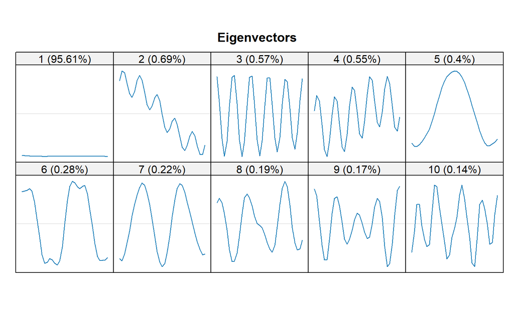

```r
ssa1 <- ssa(train1, L = 35)
plot(ssa1, type = "vectors")
```

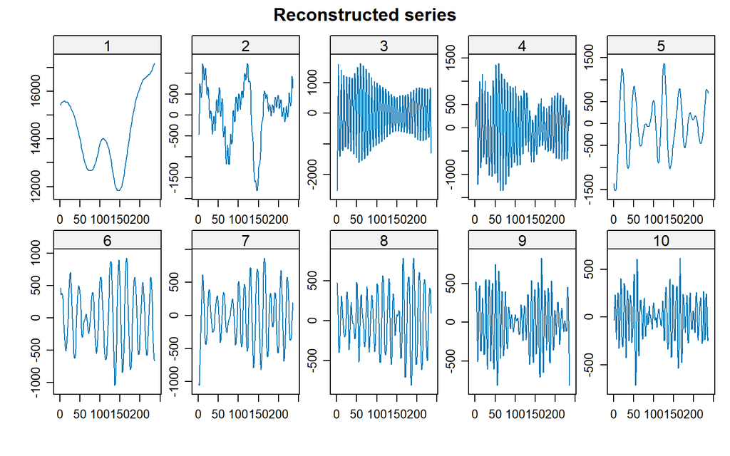

```r
plot(ssa1, type = "series", groups = 1:10)
```

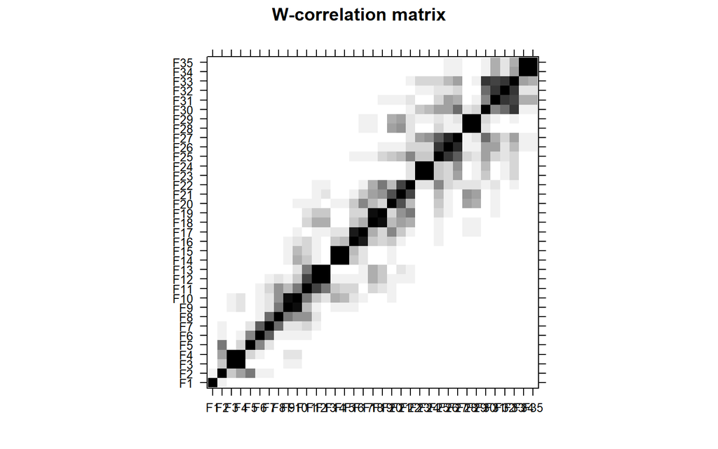

```r
plot(ssa1, type = "wcor")
```

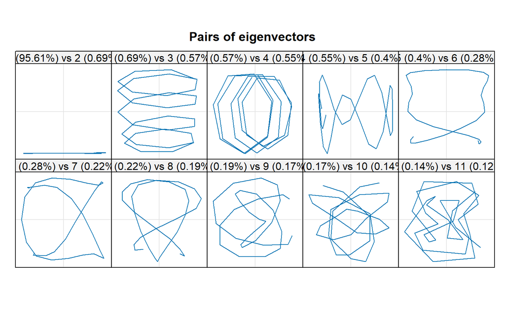

```r
plot(ssa1,type="paired")
```

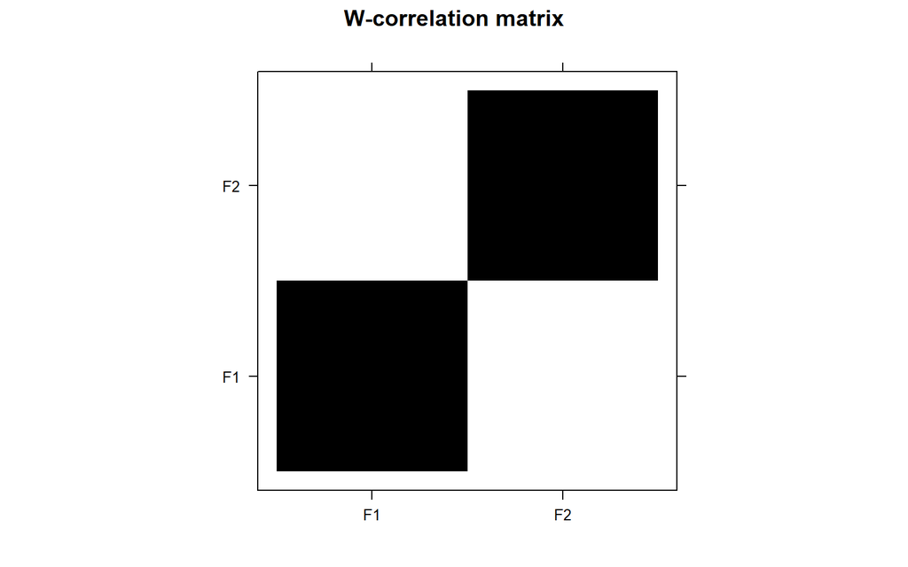

```r
g = list(c(1,2,5), c(3,4))

wcor(ssa1, groups = g) %>% plot()
```

#### Reconstruction

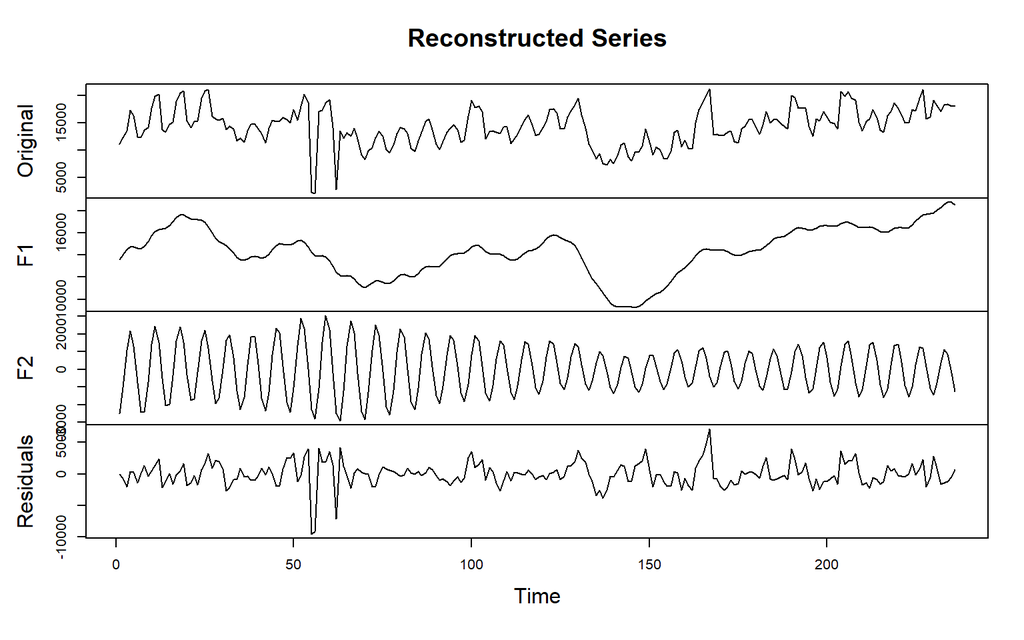

```r
recon1 <- reconstruct(ssa1, groups = g)
plot(recon1)
```

```r
## 1 dan 5 ## 3 dan 4 ## 9 dan 10

build1 <- build_c(recon1,2)
accuracy(build1, train1)
```

```
##                 ME     RMSE      MAE       MPE     MAPE      ACF1 Theil's U
## Test set -8.390131 1929.949 1371.874 -5.348478 13.61084 0.3230281 0.5794567
```

#### RForecast

```r
ssa.f1 <- rforecast(ssa1, len = length(test1),groups = g)
build.f1 <- build_c(ssa.f1,2)

accuracy(ts(build.f1), ts(test1))
```

```
##                 ME     RMSE      MAE       MPE     MAPE     ACF1 Theil's U
## Test set -384.5522 2630.254 2285.389 -3.937223 12.63538 0.771925   1.40336
```

### Skenario 2

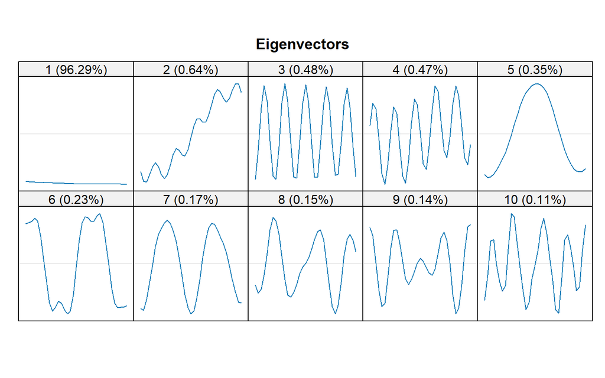

```r
ssa2 <- ssa(train2, L = 35)
plot(ssa2, type = "vectors")
```

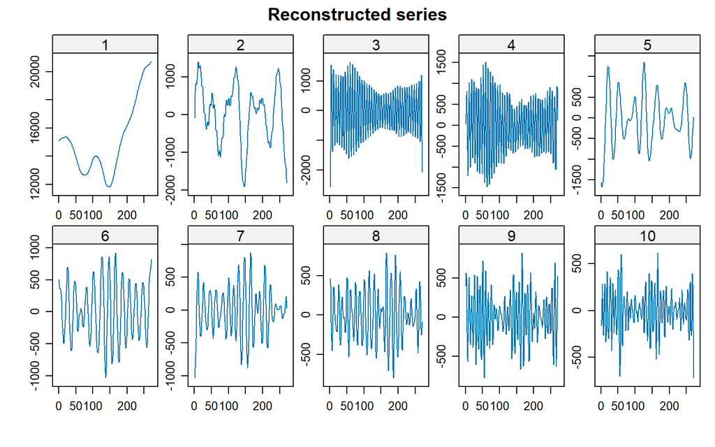

```r
plot(ssa2, type = "series", groups = 1:10)
```

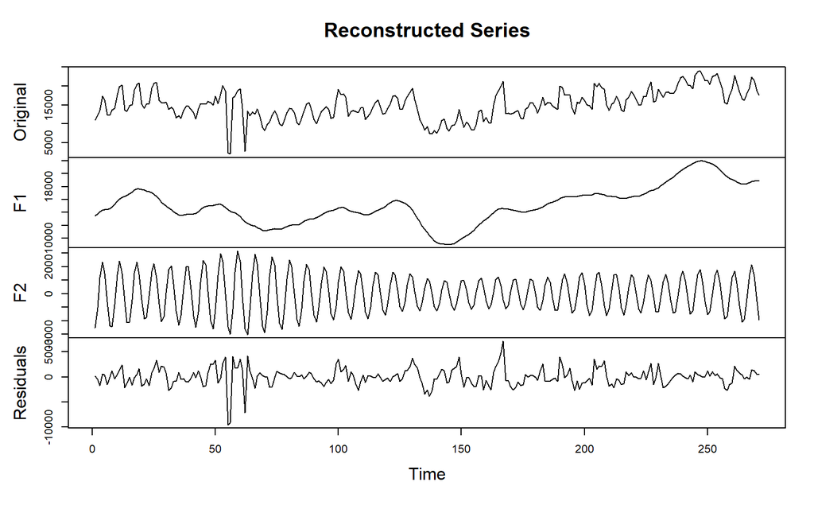

```r
g2 <- list(c(1,2,5), c(3,4))

recon2 <- reconstruct(ssa2, groups = g2)
plot(recon2)
```

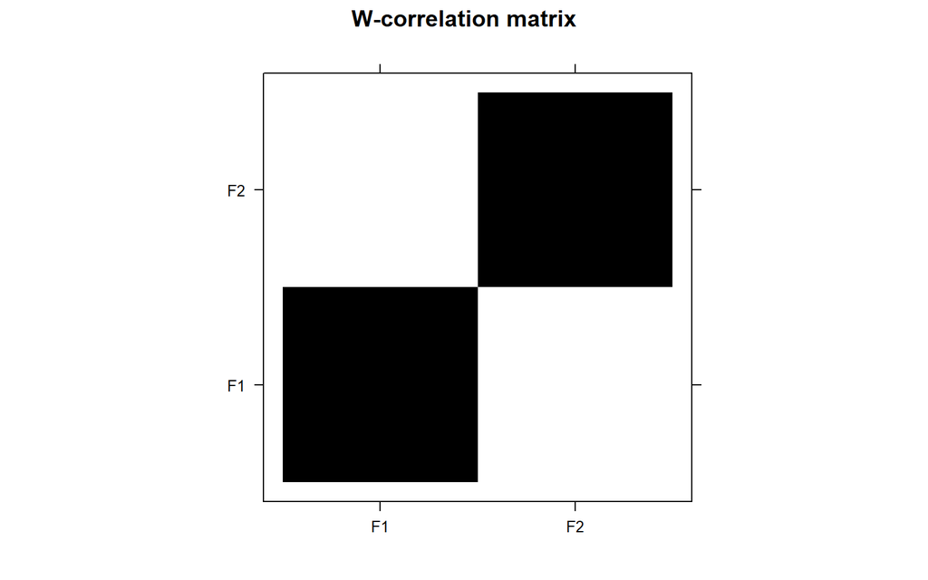

```r
wcor(ssa2, groups = g2) %>% plot()
```

#### Reconstruction

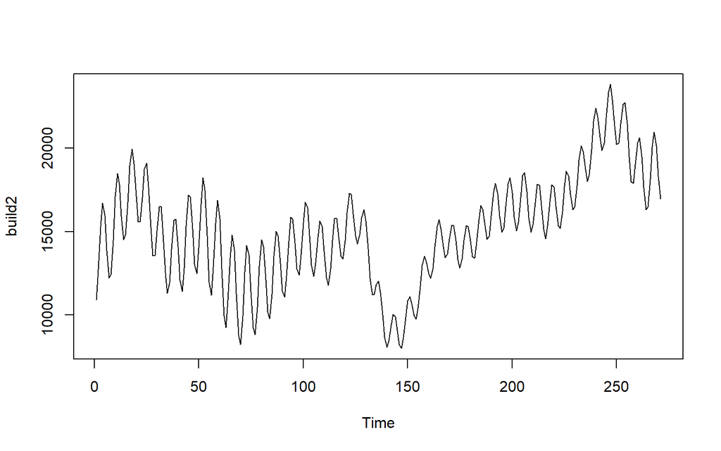

```r
build2 <- build_c(recon2,2)
plot(build2)
```

```r
accuracy(build2, train2)
```

```
##                ME     RMSE      MAE       MPE     MAPE      ACF1 Theil's U
## Test set 6.608448 1841.122 1289.684 -4.646188 12.35276 0.3340188 0.5800859
```

#### RForecast

```r
ssa.f2 <- rforecast(ssa2, len = length(test2),groups = g2)
build.f2 <- build_c(ssa.f2,2)

accuracy(ts(build.f2), ts(test2))
```

```
##                 ME     RMSE      MAE       MPE     MAPE      ACF1 Theil's U
## Test set -2553.836 3151.777 2768.524 -15.60428 16.56736 0.6167808   1.71139
```

### Skenario 3

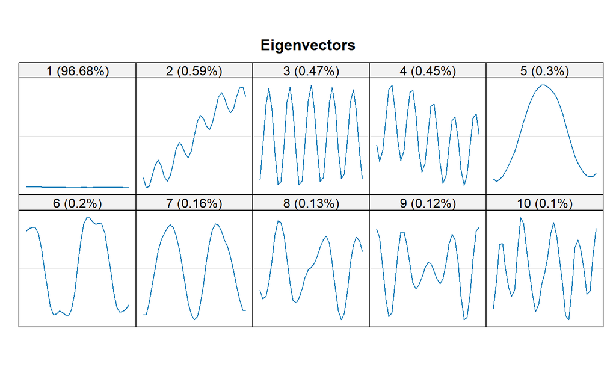

```r
ssa3 <- ssa(train3, L = 35)
plot(ssa3, type = "vectors")
```

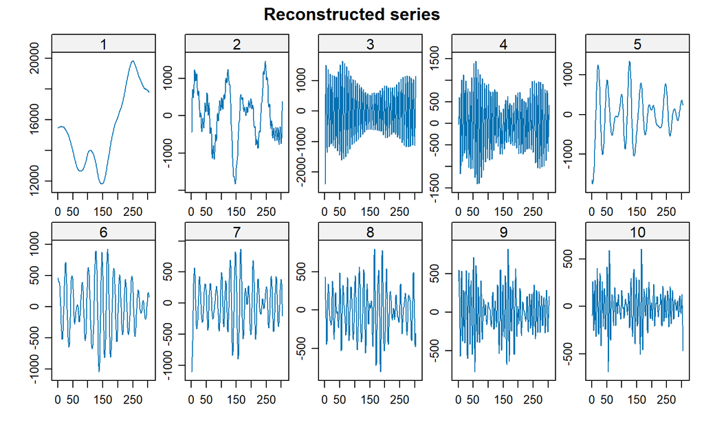

```r
plot(ssa3, type = "series", groups = 1:10)
```

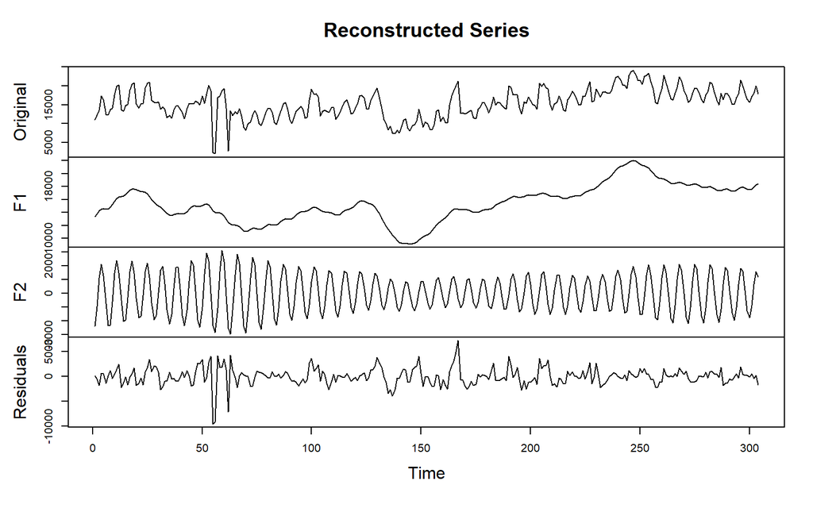

```r
g3 <- list(c(1,2,5), c(3,4))
recon3 <- reconstruct(ssa3, groups = g3)
plot(recon3)
```

#### Reconstruction

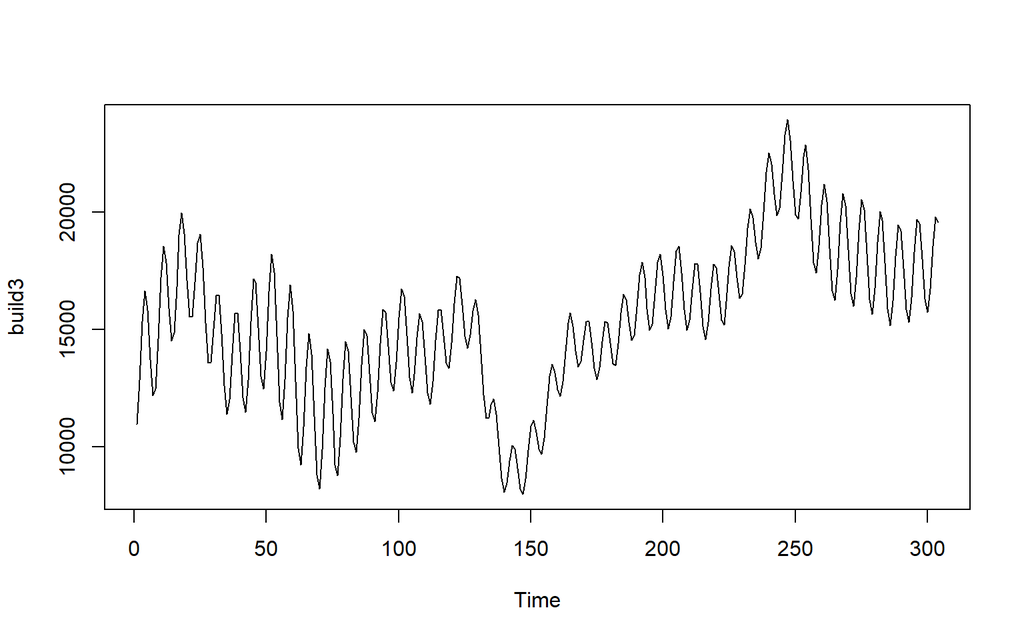

```r
build3 <- build_c(recon3,2)
plot(build3)
```

```r
accuracy(build3, train3)
```

```
##                ME     RMSE      MAE       MPE     MAPE      ACF1 Theil's U
## Test set -7.37457 1757.716 1222.512 -4.220736 11.40271 0.3292959  0.578902
```

#### Rforecast

```r
ssa.f3 <- rforecast(ssa3, len = length(test3),groups = g3)
build.f3 <- build_c(ssa.f3,2)

accuracy(ts(build.f3), ts(test3))
```

```
##                 ME    RMSE      MAE       MPE     MAPE      ACF1 Theil's U
## Test set -490.8572 2080.66 1759.361 -4.253282 10.08016 0.6283651 0.9088115
```

### SSA SUMMARY

```r
## metrics summary
metrics.ssa <- rbind(accuracy(build1, train1), accuracy(ts(build.f1), ts(test1)),
                 accuracy(build2, train2), accuracy(ts(build.f2), ts(test2)),
                 accuracy(build3, train3), accuracy(ts(build.f3), ts(test3)))

rownames(metrics.ssa) <- c("Train1", "Test1", "Train2", "Test2", "Train3", "Test3")

metrics.ssa <- metrics.ssa %>% as.data.frame %>%  select(RMSE,MAPE)

metrics.ssa
```

```
##            RMSE     MAPE
## Train1 1929.949 13.61084
## Test1  2630.254 12.63538
## Train2 1841.122 12.35276
## Test2  3151.777 16.56736
## Train3 1757.716 11.40271
## Test3  2080.660 10.08016
```

## Forecasting 120 hari kedepan dengan skenario 3

```r
final.forecast.sarima <- forecast::forecast(model.fix3, h = 120+29)
final.forecast.ssa <- rforecast(ssa3, len = 120+29,groups = g3)
```

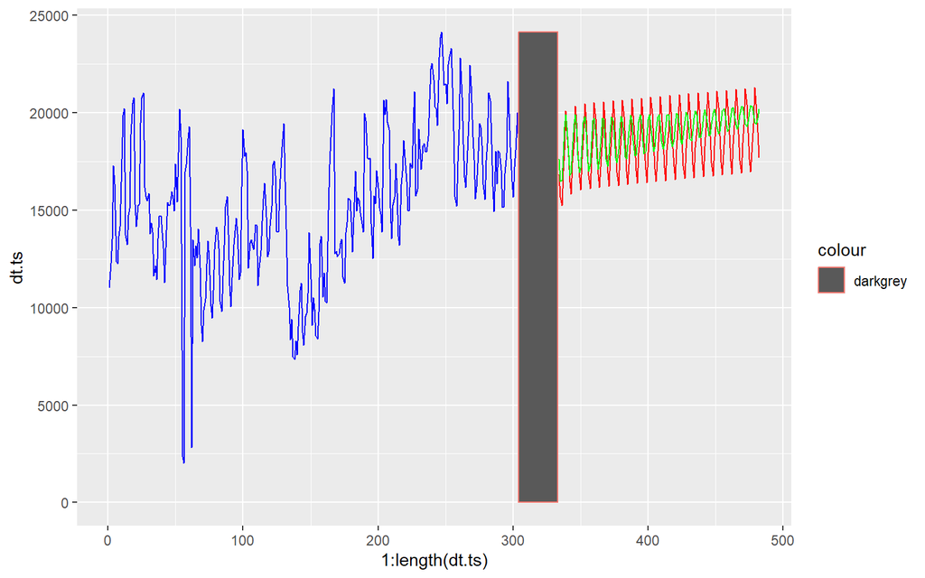

```r
ggplot()+
  geom_line(aes(x=1:length(dt.ts), y=dt.ts), color="blue")+
  geom_rect(aes(xmin = length(train3), xmax = length(dt.ts), ymin = 0, ymax = max(dt.ts), colour = "darkgrey"),alpha=1)+
  geom_line(aes(x=(1:length(final.forecast.sarima$mean)+length(dt.ts)), y=final.forecast.sarima$mean), color="red")+
  geom_line(aes(x=(1:length(final.forecast.sarima$mean)+length(dt.ts)), y=build_c(final.forecast.ssa,2)), color="green")
```